# Comparative analysis

Laura Ospina-Rozo

27/12/2021

The following code is written in the R programming language.

# Libraries

Install

```r
install.packages("dplyr")
install.packages("plot.matrix")
install.packages("tidyverse")
install.packages("phylogram")
install.packages("devtools")
devtools::install_github("eliocamp/ggnewscale")
install.packages("kableExtra")
install.packages("ggExtra")


install.packages("MCMCglmm")
install.packages("ggtree")
install.packages("geiger")
install.packages("ggnewscale")
install.packages("phangorn")
install.packages("ape")
install.packages("caper")
install.packages("phytools")
```

```r
#For PCA
library(Hmisc) # To obtain p values of correlations
library(psych) # For PCA
library(plot.matrix) # For plot Matrix in the supplementary
library(RColorBrewer) # palette
library(gridExtra) # join plot

# Plots
library(ggplot2) # graphs
library(RColorBrewer) # palette

# For phylogenetic comparative analysis

### Install packages ####
#if (!requireNamespace("BiocManager", quietly = TRUE))
#  install.packages("BiocManager")

#BiocManager::install("ggtree") #need BiocManager to install, so run previous command


#library(phylogram)
#library(ggtree)
#library(devtools)
#library(ggnewscale)
#
#library(phangorn)
#library(caper)

# Data
library(kableExtra) # Style tables in the HTML file
library(pavo) # Processing spectral data
library(jtools) # Reporting Results from Linear Models


# For MCMCglmm

library(MCMCglmm)
library(ggtree)
library(ape)
library(geiger) # for name.check() in run_mcmc()
library(ggnewscale) # for new_scale_fill()
library(phangorn) # for making MCC tree from 1300 trees using maxCladeCred()


# For PGLs
library(caper) # for pgls()
library(phytools) # for phylosig()

# Data
library(dplyr) # Data wrangling
library(tidyverse) # Data wrangling
```

# Data Processing

## Optical properties

### Sorting data frames

```r
#Import data
refl1<-read.csv("../Data/1_Reflectance_HRBatch.csv") # HR batch
refl2<-read.csv("../Data/2_Reflectance_FirstBatch.csv") # original
TopTrans<-read.csv("../Data/3_Transmittance_HRBatch.csv") # transmittance
theorySun<-read.csv("../Data/4_SunIrradiance.csv") # Sun irradiance


#Fix the column names and convert to rspec object
refl1 <-
  refl1 %>%
  dplyr::select(sort(tidyselect::peek_vars())) %>%
  dplyr::select(wl, everything()) %>%
  filter(wl >= 400 & wl <= 1700) %>%
  dplyr::select(-clor2, #same as clor 12 in refl2
         -rpmt1, -vrid1, -vrid2, -ocul1, # locality missing
         -rose1) %>% # no ecol variables available
  rename (
    anom03 = anom1,
    anom02 = anom2,
    atki03 = atki1,
    atki04 = atki2,
    aurs03 = aurs1,
    aurs04 = aurs2,
    clor17 = clor1,
    conc05 = conc1,
    conc06 = conc2,
    ecry04 = ecry1,
    ecry05 = ecry2,
    fchi03 = fchi1,
    fchi04 = fchi2,
    gray04 = gray1,
    gray05 = gray2,
    hirs15 = hirs1,
    hirs16 = hirs2,
    lats04 = lats1,
    lats05 = lats2,
    mcla03 = mcla1,
    macl06 = mclm1,
    macl07 = mclm2,
    narm04 = narm1,
    narm05 = narm2,
    pczo05 = ocul2,
    pczv04 = oliv1,
    pczv05 = oliv2,
    opal03 = opal1,
    pali08 = pali1,
    pali09 = pali2,
    poro16 = poro1,
    poro17 = poro2,
    pczp05 = ppsi1,
    pczp06 = ppsi2,
    prsi04 = prsi1,
    prsi05 = prsi2,
    prsi06 = prsi3,
    pvul05 = pvul1,
    pvul06 = pvul2,
    rayn04 = rayn1,
    rayn05 = rayn2,
    repa03 = rpan1,
    reps03 = rpmm1,
    smgg03 = smgd1,
    smgg04 = smgd2,
    tars05 = tars1,
    tars06 = tars2,
    xyle07 = xyln1,
    xyle08 = xyln2,
    xyle09 = xyln3 ) %>%  #rename to fuse with the other data set
  as.rspec(.) %>%
  procspec(.,fixneg = "zero")


refl2 <-
  refl2 %>%
  dplyr::select(sort(tidyselect::peek_vars())) %>%
  dplyr::select(wl, everything()) %>%
  filter(wl >= 400 & wl <= 1700) %>%
  dplyr::select(-ambl03, -anom02, -black, -mima03,
         -oliv03, -para01, -para02, -saul03,
         -velu00, -vrdi01, -xyle03) %>% #removed. Location not available
  rename (velu05 = flin01,
          velu04 = flin02,
          narm03 = namr03,
          rept01 = rep201,
          rept02 = rep202,
          rept03 = rep203,
          rubi03 = sutr01,
          rubi04 = sutr02,
          rubi05 = sutr03,
          rubi06 = sutr04) %>%  # renamed
  as.rspec(.) %>%
  procspec(.,fixneg = "zero")


TopTrans <-
  TopTrans %>%
  dplyr::select(sort(tidyselect::peek_vars())) %>%
  dplyr::select(wl, everything()) %>%
  filter(wl >= 400 & wl <= 1700) %>%
  dplyr::select(-clor2t, #same as clor 12 in refl2
         -rpmt1t, -vrid1t, -vrid2t, -ocul1t, # locality missing
         -rose1t) %>%   # no ecol variables available
  rename (
    anom03 = anom1t,
    anom02 = anom2t,
    atki03 = atki1t,
    atki04 = atki2t,
    aurs03 = aurs1t,
    aurs04 = aurs2t,
    clor17 = clor1t,
    conc05 = conc1t,
    conc06 = conc2t,
    ecry04 = ecry1t,
    ecry05 = ecry2t,
    fchi03 = fchi1t,
    fchi04 = fchi2t,
    gray04 = gray1t,
    gray05 = gray2t,
    hirs15 = hirs1t,
    hirs16 = hirs2t,
    lats04 = lats1t,
    lats05 = lats2t,
    mcla03 = mcla1t,
    macl06 = mclm1t,
    macl07 = mclm2t,
    narm04 = narm1t,
    narm05 = narm2t,
    pczo05 = ocul2t,
    pczv04 = oliv1t,
    pczv05 = oliv2t,
    opal03 = opal1t,
    pali08 = pali1t,
    pali09 = pali2t,
    poro16 = poro1t,
    poro17 = poro2t,
    pczp05 = ppsi1t,
    pczp06 = ppsi2t,
    prsi04 = prsi1t,
    prsi05 = prsi2t,
    prsi06 = prsi3t,
    pvul05 = pvul1t,
    pvul06 = pvul2t,
    rayn04 = rayn1t,
    rayn05 = rayn2t,
    repa03 = rpan1t,
    reps03 = rpmm1t,
    smgg03 = smgd1t,
    smgg04 = smgd2t,
    tars05 = tars1t,
    tars06 = tars2t,
    xyle07 = xyln1t,
    xyle08 = xyln2t,
    xyle09 = xyln3t ) %>%  #rename to fuse with the other data set
  as.rspec(.) %>%
  procspec(.,fixneg = "zero")


# Convert the sun irradiance into an rspec object

theorySun <-
  theorySun %>%
  filter(wl >= 400 & wl <= 1700) %>%
  as.rspec(.) %>%
  procspec(.,fixneg = "zero")


# Produce the final data frames for calculating irradiance

Transmitance <-
  TopTrans %>%
  mutate(Sun = theorySun$irradiance) # Add Sun irradiance as the last column

Reflectance <-
  data.frame (refl1,refl2[,2:length(refl2)]) %>%
  dplyr::select(sort(tidyselect::peek_vars())) %>%
  select(wl, everything()) %>%
  as.rspec(.) %>%
  procspec(.,fixneg = "zero") %>%
  mutate(Sun = theorySun$irradiance) # Add Sun irradiance as the last column
```

### Calculate reflectivity

#### Preliminary values per wavelength

This function multiplies the irradiance of the sun * the reflectance at each wavelength

```r
# 1) Define the following function to find the multiplication

Find.multiplication<-function(s){
  vector2<-rep("NA", length(s[ , 1]))
  for( i in 2 : length(s) - 1){
    for (y in 1 : length(s[ , 1])){
      vector2[y] <- s[y, i] * s[y, "Sun"] # multiply each column by the last one
    }
    s[i] <- as.numeric(vector2)
  }
  return(s)
}

# 2) Apply
PrelValuesRefl <- Find.multiplication(Reflectance)

# 3) Clean up preliminary values for reflectivity
PrelValuesRefl <-
  PrelValuesRefl %>%
  dplyr::select (-wl, # the wavelengths were altered, eliminate
          -Sun) %>% # Sun irradiance not required anymore, eliminate
  mutate (wl = Reflectance$wl) %>%  # add the correct wavelength column
  dplyr::select(wl, everything()) %>% # set the wl column as column 1
  as.rspec(.) # convert to rspec object
```

#### Subset spectral bands

```r
Refl_VIS <-
  PrelValuesRefl %>%
  filter(wl <= 700)

Refl_NIR <-
  PrelValuesRefl %>%
  filter(wl >= 700)

Refl_ALL <-
  PrelValuesRefl

Sun_VIS <-
  theorySun %>%
  filter(wl <= 700)

Sun_NIR <-
  theorySun %>%
  filter(wl >= 700)
```

#### Area under the curve

```r
# Find the AUC for the samples

# "Full" spectrum 400 to 1700 nm
Sumdf1 <- summary(Refl_ALL)
B1ALL <- Sumdf1$B1

# VIS 400 to 700 nm
Sumdf2 <- summary(Refl_VIS)
B1VIS <- Sumdf2$B1

# NIR 700 to 1700 nm
Sumdf3 <- summary(Refl_NIR)
B1NIR <- Sumdf3$B1


# Find the AUC for the sun irradiance
B1SunALL <- summary(theorySun)$B1
B1SunVIS <- summary(Sun_VIS)$B1
B1SunNIR <- summary(Sun_NIR)$B1
```

#### Standardise

Divide the vectors with the AUC per species, by the AUC of the sun for each spectral range. This step is useful to express reflectivity as the percentage of light comming from the sun, reflected by the beetle on each spectral range

```r
Reflectivity <- data.frame(
  "ind"= names(PrelValuesRefl[2:length(PrelValuesRefl)]),
  "R_ALL"= B1ALL/B1SunALL,
  "R_VIS"= B1VIS/B1SunVIS,
  "R_NIR"= B1NIR/B1SunNIR)
```

### Calculate Transmissivity

#### Preliminary values per wavelength

This function multiplies the irradiance of the sun * the reflectance at each wavelength

```r
# 1)  The function has already been defined in the previous section

# 2) Apply
PrelValuesTrans <- Find.multiplication(Transmitance)

# 3) Clean up preliminary values for reflectivity
PrelValuesTrans <-
  PrelValuesTrans %>%
  dplyr::select (-wl, # the wavelengths were altered, eliminate
          -Sun) %>% # Sun irradiance not required anymore, eliminate
  mutate (wl = Transmitance$wl) %>%  # add the correct wavelength column
  dplyr::select(wl, everything()) %>% # set the wl column as column 1
  as.rspec(.) # convert to rspec object
```

#### Subset spectral bands

```r
Tran_VIS <-
  PrelValuesTrans %>%
  filter(wl <= 700)

Tran_NIR <-
  PrelValuesTrans %>%
  filter(wl >= 700)

Tran_ALL <-
  PrelValuesTrans
```

#### Area under the curve

```r
# Find the AUC for the samples

# "Full" spectrum 400 to 1700 nm
Sumdf4 <- summary(Tran_ALL)
TB1ALL <- Sumdf4$B1

# VIS 400 to 700 nm
Sumdf5 <- summary(Tran_VIS)
TB1VIS <- Sumdf5$B1

# NIR 700 to 1700 nm
Sumdf6 <- summary(Tran_NIR)
TB1NIR <- Sumdf6$B1


# Find the AUC for the sun irradiance

# This step was completed in the previous section to find reflectivity:
B1SunALL
```

```
## [1] 899.8601
```

```r
B1SunVIS
```

```
## [1] 430.9093
```

```r
B1SunNIR
```

```
## [1] 470.2416
```

#### Standardise

Divide the vectors with the AUC per species, by the AUC of the sun for each spectral range. This step is useful to express reflectivity as the percentage of light coming from the sun, reflected by the beetle on each spectral range

```r
Transmissivity <- data.frame(
  "ind"= names(PrelValuesTrans[2:length(PrelValuesTrans)]),
  "T_ALL"= TB1ALL/B1SunALL,
  "T_VIS"= TB1VIS/B1SunVIS,
  "T_NIR"= TB1NIR/B1SunNIR) %>%
  arrange(ind)
```

### Calculate Absorptivity

This parameter is calculated as Abs = 100 - (Reflectivity + Transmissivity)

```r
Reflect_sub <-
  Reflectivity %>%
  filter(ind %in% (Transmissivity$ind)) %>%
  arrange(ind)


Optical <- # A data frame with the 3 optical properties
  data.frame(Reflect_sub,Transmissivity) %>%
  dplyr::select(-ind.1) %>%
  mutate(
    A_ALL = 100 - (R_ALL + T_ALL), # Absorptivity for VIS+NIR
    A_VIS = 100 - (R_VIS + T_VIS), # Absorptivity for VIS
    A_NIR = 100 - (R_NIR + T_NIR) # Absorptivity for NIR
  )
```

### Results of this step

`Reflectivity` contains the standardized values of Reflectivity for 276 individuals.

`Optical` contains the standardized values for three optical properties Reflectivity, Transmissivity and Absorptivity for a subset of 51 individuals form the previous sample (correspondent to the same set of individuals analyzed in the heating rates chapter).

Note: Some beetles may need to be removed from the analysis because their position on the phylogeny is uncertain. Removed on 19-01-2022:

```r
Reflectivity <-
  Reflectivity %>%
  mutate (spp = substr(ind, 1, 4)) %>%
  filter (spp != "ambl"& # Amblyterus cicatricosus
          spp != "psqz"& # Pseudoschizongnatus schoenfeldti
          spp != "saul"& # Saulostomus villosus
          spp != "sqzb"& # Schizognathus burmeisteri
          spp != "sqzc"& # Schizognathus compressicornis
          spp != "sqzm"  # Schizognathus mesosternalis
            ) %>% # These species were removed. No phylogenetic info
  dplyr::select (-spp)
```

These beetles can be included in the analysis again if we get morphological information of their phylogenetic relations

## Ecological Variables

### Setting up

```r
#Data sourced from additional scripts:

#ALA Data
source("./1_ALA_variables.R")
#AWAP Data
source("./4_AWAPDailyQueries_2022.R")
```

```r
#ALA Data
vegeta <- read_csv("../Data/6_VegetationVariables.csv")
climat <- read_csv("../Data/7_ClimateVariables.csv")
```

Data wrangling and keeping only the relevant variables :

```r
climat <-
  climat %>%
  filter (species != "xyle3" &
          species != "oliv3") %>% # removed. vegetation data not available
  arrange (species) %>%
  dplyr::select (c(1,5:8,11:19)) %>%
  rename(
    over35 = avg_temp_over_35, # days over 35deg averaged through 10 years
    MaxT = avg_max_temp, # daily -> mean in one month -> mean over 10 y
    MinT = avg_min_temp, # daily -> mean in one month -> mean over 10 y
    Solar = avg_sol, # daily radiation -> mean in month -> mean over 10 y
    Vapour =avg_vpr, # vapor pressure -> mean in month -> mean over 10 y
    Clouds = cloud_cover, # cloud cover per year
    Rain = avg_rr) # rainfall per day -> mean in one month -> mean over 10 years

names(climat)
```

```
##  [1] "species"               "over35"                "MaxT"
##  [4] "MinT"                  "Solar"                 "Clouds"
##  [7] "Rain"                  "Vapour"                "avg_temp_over_35_Coll"
## [10] "avg_max_temp_Coll"     "avg_min_temp_Coll"     "avg_sol_Coll"
## [13] "avg_rr_Coll"           "avg_vpr_Coll"
```

```r
# Suffix Coll = value for the parameter in the collection month.
# No suffix = average value for this variable across the activity period

vegeta <-
  vegeta %>%
  filter (spp != "vrdi1"&
          spp != "rose05") %>% # removed. climate data not available
  arrange (spp) %>%
  dplyr::select (c(1,11:18)) # Keep only the vegetation variables

names(vegeta) <- (c("beetle", "NPP", "BareSoil", "LeafArea",
                "FPAR", "Aridity", "C3Macro", "C3Meso", "C4Mega")) # rename

EcoVar <-
  data.frame(vegeta,climat) %>%
  dplyr::select (- species) %>%
  dplyr::select (c(1,6:16)) %>%  # Keep only variables for the period of activity
  mutate (AridityN = Aridity * -1) %>%  # Because arid = closer to 0
  dplyr::select (- Aridity)
```

Note: Some beetles may need to be removed from the analysis because their position on the phylogeny is uncertain. Removed on 19-01-2022:

```r
EcoVar <-
  EcoVar %>%
  mutate (spp = substr(beetle, 1, 4)) %>%
  filter (spp != "ambl"& # Amblyterus cicatricosus
          spp != "psqz"& # Pseudoschizongnatus schoenfeldti
          spp != "saul"& # Saulostomus villosus
          spp != "sqzb"& # Schizognathus burmeisteri
          spp != "sqzc"& # Schizognathus compressicornis
          spp != "sqzm"  # Schizognathus mesosternalis
            ) %>% # These species were removed. No phylogenetic info
  dplyr::select (-spp)
```

These beetles can be included in the analysis if we get morphological information of their phylogenetic relations

Note: We obtained a data frame with all the relevant ecological variables, but it can change according to correlations. See section below.

### Correlations

To explore the correlations between the ecological variables

```r
EVarP <- EcoVar[,c(2:length(EcoVar))] # remove the categorical variables

EVarMatP<- Hmisc::rcorr(as.matrix(EVarP))
EVarR2P <- round(EVarMatP$r, 2) # R2 values
EvarCpP <- round(EVarMatP$P, 5) # p  values

# See correlations in supplementary materials section
```

Remove variables with correlations of R > 0.8

```r
EcolVar <-
  EcoVar %>%
  dplyr::select (- C3Macro, -C4Mega, -C3Meso, -MinT)

EVar <- EcolVar[,c(2:length(EcolVar))] # remove the categorical variables

EVarMat<- Hmisc::rcorr(as.matrix(EVar))
EVarR2 <- round(EVarMat$r, 2) # R2 values
EvarCp <- round(EVarMat$P, 5) # p  values
```

### PCA

#### Extract Components

```r
cord <- cor(EVar) # default: pearsons correlation coeficient
N <- dim(EVar)[1] # number of observations
cortest.bartlett(cord,n=N) # Are the variables correlated? Yes p < 0.05
```

```
## $chisq
## [1] 1693.035
##
## $p.value
## [1] 0
##
## $df
## [1] 21
```

```r
eigVal <- eigen(cord) # Extract eigen values
vectorev <- eigVal$vectors # vector with the eigen values
# Extract components
compv <- prcomp(EVar, retx=TRUE, center=TRUE, scale. = TRUE) # components
load<-compv$rotation # Loadings matrix
```

#### Scree Plot

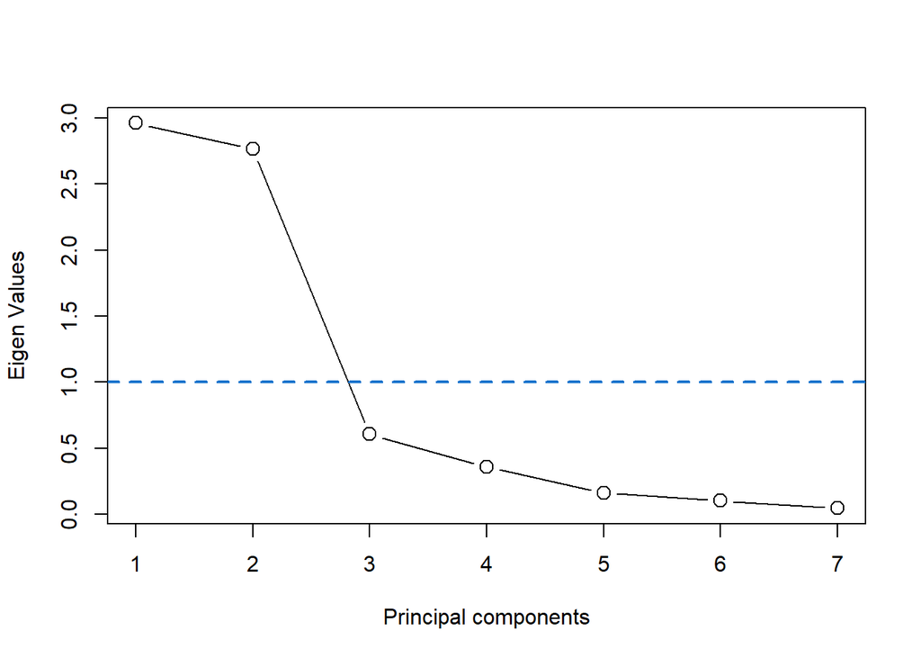

```r
{ plot(c(1:length(eigVal$values)),eigVal$values,type="b", cex=1.4,
     ylab="Eigen Values",xlab="Principal components")
abline(h=1,col="dodgerblue3",lwd=2,lty=2)}
```

#### Variance explained

```r
summary(compv)
```

```
## Importance of components:
##                           PC1    PC2     PC3     PC4     PC5     PC6     PC7
## Standard deviation     1.7206 1.6629 0.77800 0.59788 0.40371 0.31950 0.21572
## Proportion of Variance 0.4229 0.3950 0.08647 0.05107 0.02328 0.01458 0.00665
## Cumulative Proportion  0.4229 0.8179 0.90442 0.95549 0.97877 0.99335 1.00000
```

#### Loadings Matrix

visualization

```r
brewer.pal(n = 7, name = "PRGn")
```

```
## [1] "#762A83" "#AF8DC3" "#E7D4E8" "#F7F7F7" "#D9F0D3" "#7FBF7B" "#1B7837"
```

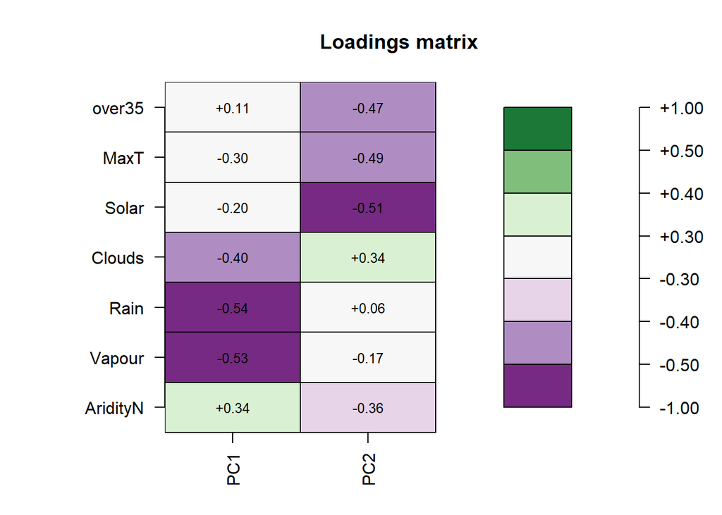

```r
par(mar=c(4, 8, 4, 4))

plot(load[,1:2],cex=0.8,breaks=c(-1,-0.5,-0.4,-0.3,0.3,0.4,0.5,1),
     las=2,ylab=" ",xlab=" ",
     digits=2,
     col=c(
       "#762A83", "#AF8DC3",
       "#E7D4E8", "#F7F7F7",
       "#D9F0D3", "#7FBF7B",
       "#1B7837"
     ),
     main="Loadings matrix ")
```

Lower PC1 = higher humidity (vapour, rain and clouds) lower aridity. Lower PC2 = higher solar radiation, higher max temp, more days above 35 and more aridity

#### Plot

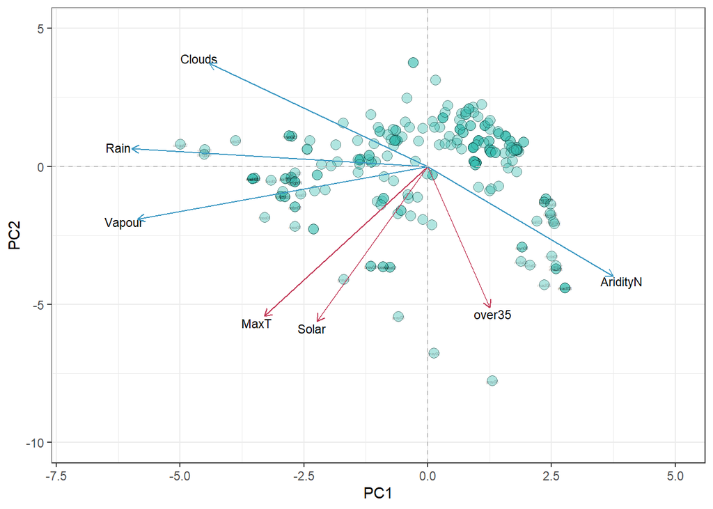

```r
# brewer.pal(n = 7, name = "Accent")

# Extract PC axes for plotting
PCAvalues <- data.frame(Species = EcolVar$beetle,
                        compv$x)

# Extract loadings of the variables
PCAloadings <- data.frame(Variables = rownames(compv$rotation), compv$rotation)

# PC1 vs PC2
ggplot(PCAvalues, aes(x = PC1, y = PC2)) +
  geom_point(fill="#39BEB1",col="black",pch=21,size=3.2,alpha=0.4)+
  theme_bw()+
  geom_text(data = subset (PCAvalues, PC1 > 2 | PC1 < -2.5 | PC2 < -2.5),
            alpha=.3, size=1, aes(label=Species),col="black")+
  annotate("text", size=3,
           x = (PCAloadings$PC1*11.5),
           y = (PCAloadings$PC2*11.5),
           label = (PCAloadings$Variables))+
  geom_segment(data = PCAloadings[c(1,2,3),],
           aes(x = 0, y = 0,
               xend = (PC1*11), yend = (PC2*11)),
           arrow = arrow(
             length = unit(1/2,"picas")),
             color = "#c23a58") +
  geom_segment(data = PCAloadings[c(4,5,6,7),],
           aes(x = 0, y = 0,
               xend = (PC1*11), yend = (PC2*11)),
           arrow = arrow(
             length = unit(1/2,"picas")),
             color = "#3a97c2") +
  geom_hline(yintercept = 0, linetype ="dashed",colour="gray")+
  geom_vline(xintercept = 0, linetype ="dashed",colour="gray") +
  ylim(-10, 5) +
  xlim(-7, 5)
```

## Consolidated Data Frames

### Reflectivity

Include the additional variables: NIR-VIS residuals, Size and Species name as written in the phylogeny

NIR - VIS residuals:

This step in required because visible and NIR reflectivity are expected to be correlated. Using the residuals of the correlation between these two properties is useful to explore if NIR reflectivity is driven by pressures different than the ones affecting visible (mainly thermoregulation)

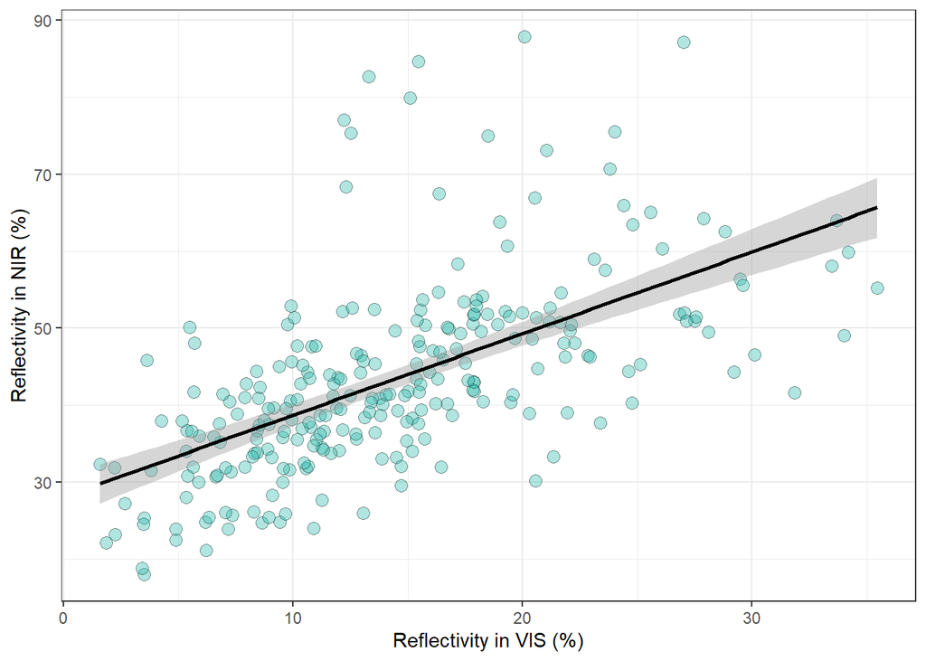

```r
#Plot of the correlation between NIR and VIS reflectivity
ggplot(data = Reflectivity, aes(x = R_VIS, y = R_NIR))+
  geom_point(size=3,alpha=0.4, pch=21,
             col="black",
             fill= "#39BEB1")+
  geom_smooth (method="lm", col="black")+
  theme_bw() +
  xlab("Reflectivity in VIS (%)") +
  ylab("Reflectivity in NIR (%)")
```

```r
# Linear model
NIRVISMod1 <- lm (Reflectivity$R_NIR ~ Reflectivity$R_VIS)

export_summs(NIRVISMod1, error_format = "SE = {std.error}")
```

|  | Model 1 |
| --- | --- |
| (Intercept) | 28.13 *** |
|  | SE = 1.41 |
| Reflectivity$R_VIS | 1.06 *** |
|  | SE = 0.09 |
| N | 261 |
| R2 | 0.36 |
| *** p < 0.001; ** p < 0.01; * p < 0.05. |  |

```r
# Include Residuals in the data frame
Reflectivity$Res <- NIRVISMod1$residuals
```

Relationship between reflectivity in NIR and the residuals:

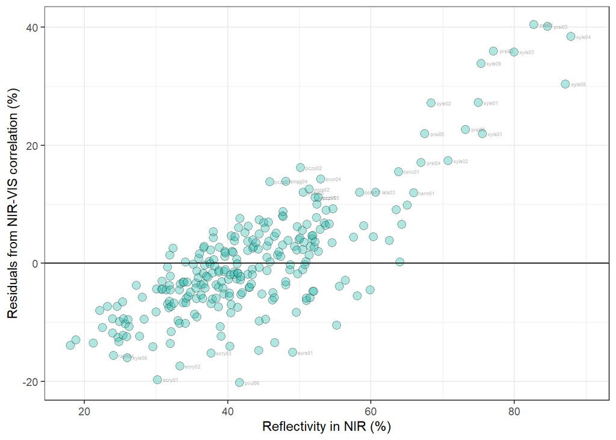

```r
ForResNIRPlot <-
  Reflectivity %>%
  dplyr::select (ind, Res, R_NIR) %>%
  arrange (R_NIR)

ggplot(data = ForResNIRPlot, aes(x= R_NIR ,y = Res))+
  geom_point(size=3,alpha=0.4, pch=21,
             col="black",
             fill= "#39BEB1")+
  geom_text(data = subset (ForResNIRPlot, Res > 10 | Res < -15),
            aes(label=ind),col="black",
            position = position_nudge(x = +1.8),
            alpha=.3, size=1.5)+
  theme_bw() +
  geom_hline(yintercept=0)+
  xlab("Reflectivity in NIR (%)") +
  ylab("Residuals from NIR-VIS correlation (%)")
```

Size:

We measured the size from calibrated photographs of the specimens. It is the length between the frontal edge of the head to the end of the abdomen.

```r
Size <- read.csv("../Data/8_Size.csv")
```

Note: Some beetles may need to be removed from the analysis because their position on the phylogeny is uncertain. Removed on 19-01-2022:

```r
Size <-
  Size %>%
  mutate (spp = substr(ind, 1, 4)) %>%
  filter (spp != "ambl"& # Amblyterus cicatricosus
          spp != "psqz"& # Pseudoschizongnatus schoenfeldti
          spp != "saul"& # Saulostomus villosus
          spp != "sqzb"& # Schizognathus burmeisteri
          spp != "sqzc"& # Schizognathus compressicornis
          spp != "sqzm"  # Schizognathus mesosternalis
            ) %>% # These species were removed. No phylogenetic info
  dplyr::select (-spp)
```

These beetles can be included in the analysis if we get morphological information of their phylogenetic relations

Phylogeny Name:

```r
SppNames <- read.csv("../Data/9_CodesAndSpecies.csv")

SppNames <-
  SppNames %>%
  mutate (spp = substr(Ind, 1, 4)) %>%
  filter (spp != "ambl"& # Amblyterus cicatricosus
          spp != "psqz"& # Pseudoschizongnatus schoenfeldti
          spp != "saul"& # Saulostomus villosus
          spp != "sqzb"& # Schizognathus burmeisteri
          spp != "sqzc"& # Schizognathus compressicornis
          spp != "sqzm"  # Schizognathus mesosternalis
            ) %>% # These species were removed. No phylogenetic info
  dplyr::select (-spp) %>%
  arrange(Ind)
```

Final Consolidated:

Create a consolidated file with the ecological variables, reflectivity and size

```r
Cons1 <-
  data.frame(Reflectivity,PCAvalues[ , 1 : 3], Size, SppNames) %>%
  dplyr::select(-ind.1,-Species,-Ind)

write.csv(Cons1,"../Data/20220119ConsolidatedFile.csv")
```

### Species Reflectivity

```r
# Summarise the data frame: one value per species (each variable)

Cons1agg <-
  Cons1 %>%
  dplyr::select (-ind) %>% # remove individual id
  dplyr::select (phylogeny_name, everything ()) %>% # order columns
  group_by (phylogeny_name) %>%  # group
  summarise (across(everything(), list(mean))) # mean

# Modify to make it compatible with tree tips
ConsAgg <- as.data.frame(Cons1agg) # convert to a data frame
rownames(ConsAgg) <- ConsAgg[, 1] # make species the row names
ConsAgg <- ConsAgg [,2:length(ConsAgg)] # eliminate spp name (redundant)

# Separate the data frames
# Useful for plotting in the tree
names(ConsAgg) <- c("TOT", "VIS", "NIR", "Res",
                    "PC1", "PC2", "Size" )

TOTdf <- ConsAgg %>% dplyr::select (TOT)
VISdf <- ConsAgg %>% dplyr::select (VIS)
NIRdf <- ConsAgg %>% dplyr::select (NIR)
Resdf <- ConsAgg %>% dplyr::select (Res)
PC1df <- ConsAgg %>% dplyr::select (PC1)
PC2df <- ConsAgg %>% dplyr::select (PC2)
Sizdf <- ConsAgg %>% dplyr::select (Size)
```

### Absorptivity

```r
Cons2 <-
  Cons1 %>%
  filter(ind %in% (Optical$ind)) %>% # Subset the reflectivity set
  arrange(ind) %>%
  dplyr::select(PC1, PC2, size) %>% # Keep only the PCs and size
  bind_cols(. , Optical) %>% # join with the 'Optical' Data frame
  dplyr::select(ind, everything()) # rearrange the column order
```

# Testing correlation with environment

## Reflectivity

### Test Relations

Lower PC1 = higher humidity (vapour, rain and clouds) lower aridity. Lower PC2 = higher solar radiation, higher max temp, more days above 35 and more aridity

#### Models

```r
EcoMod_TOT <- lm( data = Cons1, R_ALL ~ PC1 + PC2 + size + PC1*size + PC2*size)

EcoMod_VIS <- lm( data = Cons1, R_VIS ~ PC1 + PC2 + size + PC1*size + PC2*size)

EcoMod_NIR <- lm( data = Cons1, R_NIR ~ PC1 + PC2 + size + PC1*size + PC2*size)

EcoMod_Res <- lm( data = Cons1, Res ~ PC1 + PC2 + size + PC1*size + PC2*size)

export_summs(EcoMod_TOT, EcoMod_VIS, EcoMod_NIR, EcoMod_Res,
             error_format = "SE = {std.error} p = {p.value}",
             model.names = c("TOT", "VIS", "NIR", "Res"))
```

|  | TOT | VIS | NIR | Res |
| --- | --- | --- | --- | --- |
| (Intercept) | 20.48 *** | 5.80 | 33.93 *** | -0.33 |
|  | SE = 3.98 p = 0.00 | SE = 3.03 p = 0.06 | SE = 5.56 p = 0.00 | SE = 4.31 p = 0.94 |
| PC1 | -2.93 | -3.55 * | -2.36 | 1.39 |
|  | SE = 1.93 p = 0.13 | SE = 1.47 p = 0.02 | SE = 2.70 p = 0.38 | SE = 2.09 p = 0.51 |
| PC2 | 1.51 | -3.61 * | 6.20 | 10.02 *** |
|  | SE = 2.29 p = 0.51 | SE = 1.74 p = 0.04 | SE = 3.20 p = 0.05 | SE = 2.48 p = 0.00 |
| size | 3.75 * | 3.65 ** | 3.84 | -0.03 |
|  | SE = 1.71 p = 0.03 | SE = 1.30 p = 0.01 | SE = 2.39 p = 0.11 | SE = 1.85 p = 0.99 |
| PC1:size | 1.25 | 1.46 * | 1.07 | -0.48 |
|  | SE = 0.84 p = 0.14 | SE = 0.64 p = 0.02 | SE = 1.17 p = 0.36 | SE = 0.91 p = 0.60 |
| PC2:size | -0.65 | 1.15 | -2.30 | -3.52 *** |
|  | SE = 0.92 p = 0.48 | SE = 0.70 p = 0.10 | SE = 1.29 p = 0.07 | SE = 1.00 p = 0.00 |
| N | 261 | 261 | 261 | 261 |
| R2 | 0.04 | 0.11 | 0.04 | 0.11 |
| *** p < 0.001; ** p < 0.01; * p < 0.05. |  |  |  |  |

If interaction was not included:

PC1 does not predict reflectivity. PC2 predicts VIS reflectivity and Residuals, but with oposite pattern: Hot and arid environments are correlated with high reflectivity in VIS, and lower (negative) NIR residuals. Size has an effect in total, nir and vis reflectivity but not in the residuals.

Interaction included in all models:

*TOT* —-

Size explains total reflectivity: overall, larger beetles reflect more light

*VIS* —-

size explains reflectivity in VIS: larger beetles generally reflect more vis light.

PC1 and PC1-Size-Interaction explain reflectivity in VIS: Beetles in humid environments reflect more VIS. And this effect is likely to be more pronounced in small beetles.

PC2 explains reflectivity in VIS: Beetles in hot/arid environments are reflect more VIS. And this pattern prevails regardless of the size of the beetle.

*Res* —-

PC2 and PC2-Size interaction explain NIR residuals: Beetles in hot/arid environments seem to reflect less NIR than the value expected by the simple correlation VIS-NIR. And this pattern is more pronounced in small beetles.

#### Plots

##### PC1

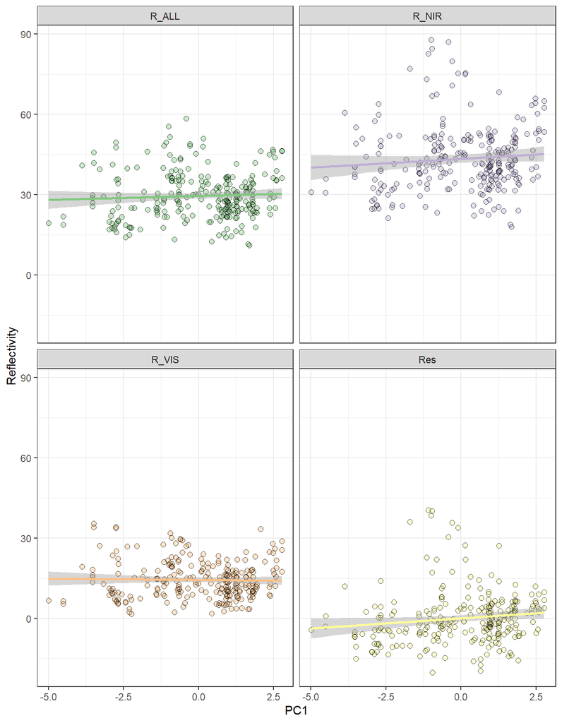

```r
toplotPC1 <-
  Cons1 %>%
  dplyr::select (-PC2,-phylogeny_name) %>%
  gather (key = spectralband,
          value = Reflectivity, - ind, -PC1, -size)   # prepare for ggplot


ggplot(toplotPC1, aes(x = PC1, y = Reflectivity, colour = spectralband))+
  geom_point(size=2,alpha=0.4)+
  geom_point(size=2, pch=21, colour="black", alpha=0.7)+
  geom_smooth (method="lm")+
  theme_bw()+
  facet_wrap(~ spectralband) +
  scale_color_brewer(palette = "Accent")+
  theme(legend.position = "none")
```

##### PC2

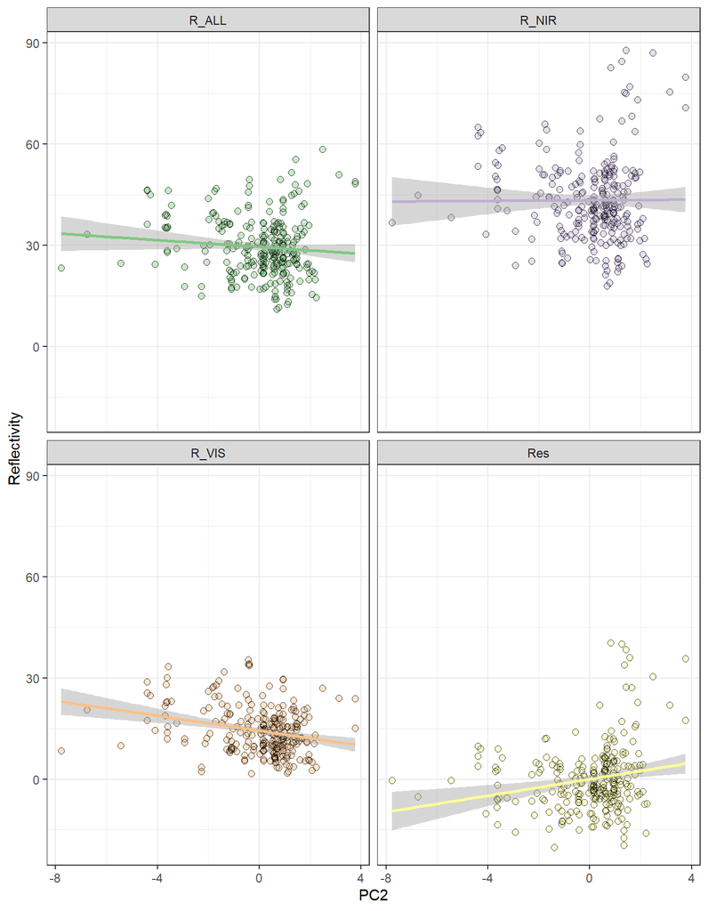

```r
toplotPC2 <-
  Cons1 %>%
  dplyr::select (-PC1,-phylogeny_name) %>%
  gather (key = spectralband,
          value = Reflectivity, - ind, -PC2, -size)   # prepare for ggplot



ggplot(toplotPC2, aes(x = PC2, y = Reflectivity, colour = spectralband))+
  geom_point(size=2,alpha=0.4)+
  geom_point(size=2, pch=21, colour="black", alpha=0.7)+
  geom_smooth (method="lm")+
  theme_bw()+
  facet_wrap(~ spectralband) +
  scale_color_brewer(palette = "Accent")+
  theme(legend.position = "none")
```

##### Size

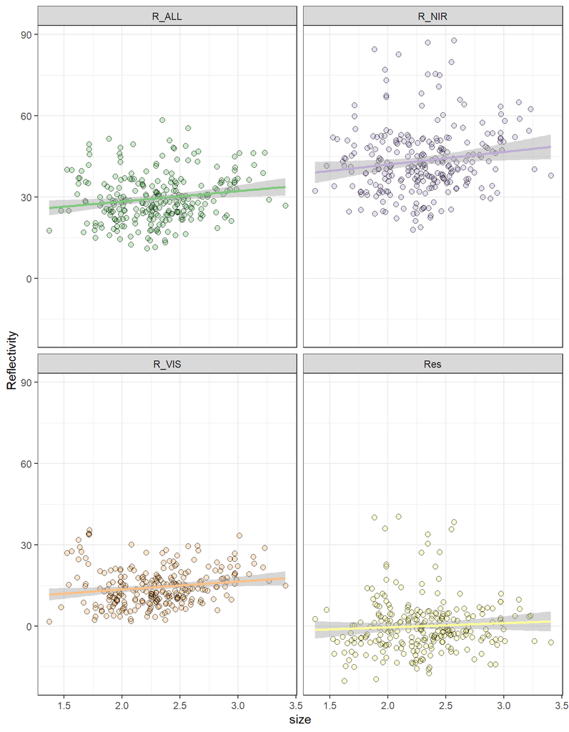

```r
toplotSize <-
  Cons1 %>%
  dplyr::select (-PC1,-phylogeny_name, -PC2) %>%
  gather (key = spectralband,
          value = Reflectivity, -ind, -size)   # prepare for ggplot

ggplot(toplotSize, aes(x = size, y = Reflectivity, colour = spectralband))+
  geom_point(size=2,alpha=0.4)+
  geom_point(size=2, pch=21, colour="black", alpha=0.7)+
  geom_smooth (method="lm")+
  theme_bw()+
  facet_wrap(~ spectralband) +
  scale_color_brewer(palette = "Accent")+
  theme(legend.position = "none")
```

## Absorptivity

### Test Relations

#### Models

```r
EcoMod_Abs_TOT <- lm( data = Cons2, A_ALL ~ PC1 + PC2 + size)

EcoMod_Abs_VIS <- lm( data = Cons2, A_VIS ~ PC1 + PC2 + size)

EcoMod_Abs_NIR <- lm( data = Cons2, A_NIR ~ PC1 + PC2 + size)

export_summs(EcoMod_Abs_TOT, EcoMod_Abs_VIS, EcoMod_Abs_NIR,
             error_format = "SE = {std.error} p = {p.value}",
             model.names = c("TOT", "VIS", "NIR"))
```

|  | TOT | VIS | NIR |
| --- | --- | --- | --- |
| (Intercept) | 42.83 *** | 75.99 *** | 12.45 |
|  | SE = 11.97 p = 0.00 | SE = 9.80 p = 0.00 | SE = 14.98 p = 0.41 |
| PC1 | -0.71 | -0.18 | -1.19 |
|  | SE = 1.14 p = 0.54 | SE = 0.93 p = 0.85 | SE = 1.43 p = 0.41 |
| PC2 | -1.48 | -0.65 | -2.25 |
|  | SE = 0.97 p = 0.13 | SE = 0.79 p = 0.41 | SE = 1.21 p = 0.07 |
| size | 4.86 | 1.31 | 8.11 |
|  | SE = 5.25 p = 0.36 | SE = 4.30 p = 0.76 | SE = 6.57 p = 0.22 |
| N | 50 | 50 | 50 |
| R2 | 0.08 | 0.02 | 0.13 |
| *** p < 0.001; ** p < 0.01; * p < 0.05. |  |  |  |

Neither PC’s, nor size can explain the absorptivity in this subset of data with a linear relation.

#### Plot PC1

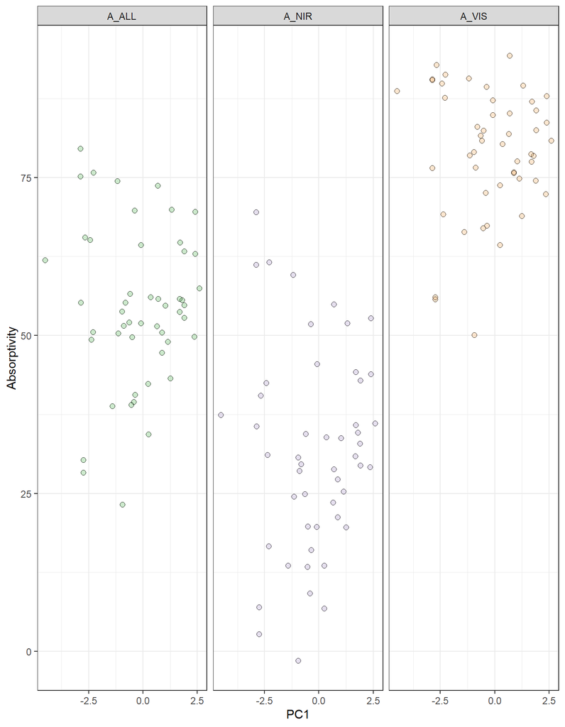

```r
toplotAPC1 <-
  Cons2 %>%
  dplyr::select (1, 2, 4, 11, 12, 13) %>%
  gather (key = spectralband,
          value = Absorptivity, - ind, -PC1, -size)   # prepare for ggplot


ggplot(toplotAPC1, aes(x = PC1, y = Absorptivity, colour = spectralband))+
  geom_point(size=2,alpha=0.4)+
  geom_point(size=2, pch=21, colour="black", alpha=0.7)+
  theme_bw()+
  facet_wrap(~ spectralband) +
  scale_color_brewer(palette = "Accent")+
  theme(legend.position = "none")
```

#### Plot PC2

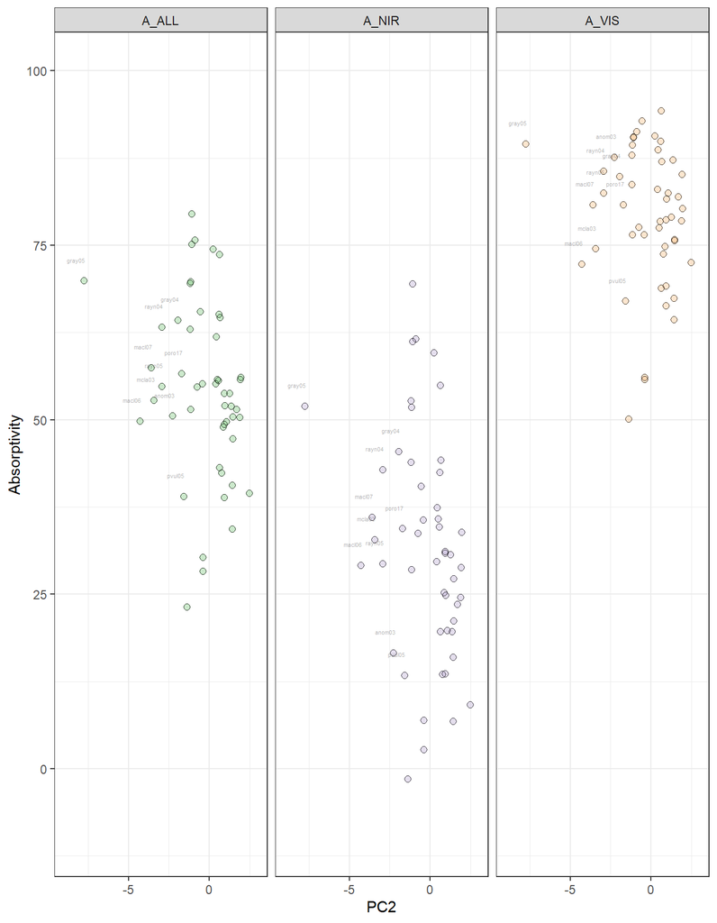

```r
toplotAPC2 <-
  Cons2 %>%
  dplyr::select (1, 3, 4, 11, 12, 13) %>%
  gather (key = spectralband,
          value = Absorptivity, - ind, -PC2, -size)   # prepare for ggplot

ggplot(toplotAPC2, aes(x = PC2, y = Absorptivity, colour = spectralband))+
  geom_point(size=2,alpha=0.4)+
  geom_point(size=2, pch=21, colour="black", alpha=0.7)+
  geom_text(data = subset (toplotAPC2, PC2 < -1.5),
            aes(label=ind),col="black",
            position = position_nudge(x = -0.5, y= 3),
            alpha=.3, size=1.5)+
  ylim(-10,100)+
  xlim(-9,3)+
  theme_bw()+
  facet_wrap(~ spectralband) +
  scale_color_brewer(palette = "Accent")+
  theme(legend.position = "none")
```

# Phylogenetic Comparative analysis

## Asumptions

- Independence of each data points
- Correct distribution of the residuals
- Linear relationship between the response and the linear predictor

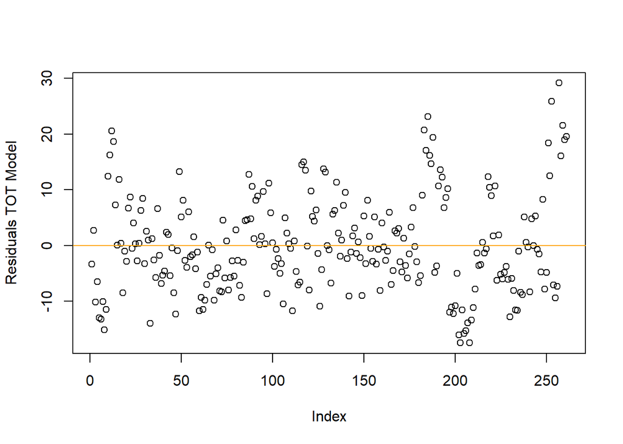

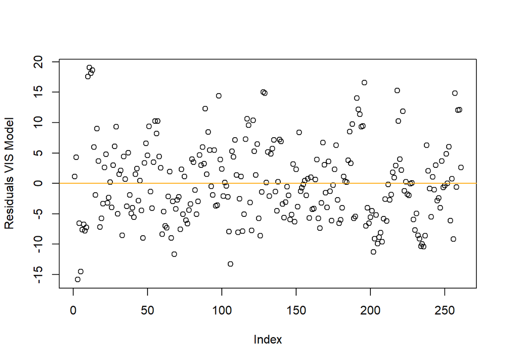

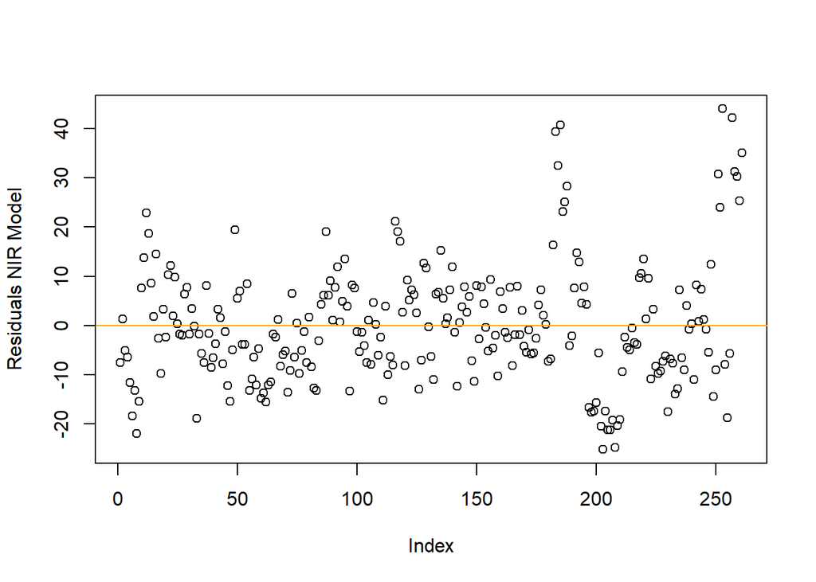

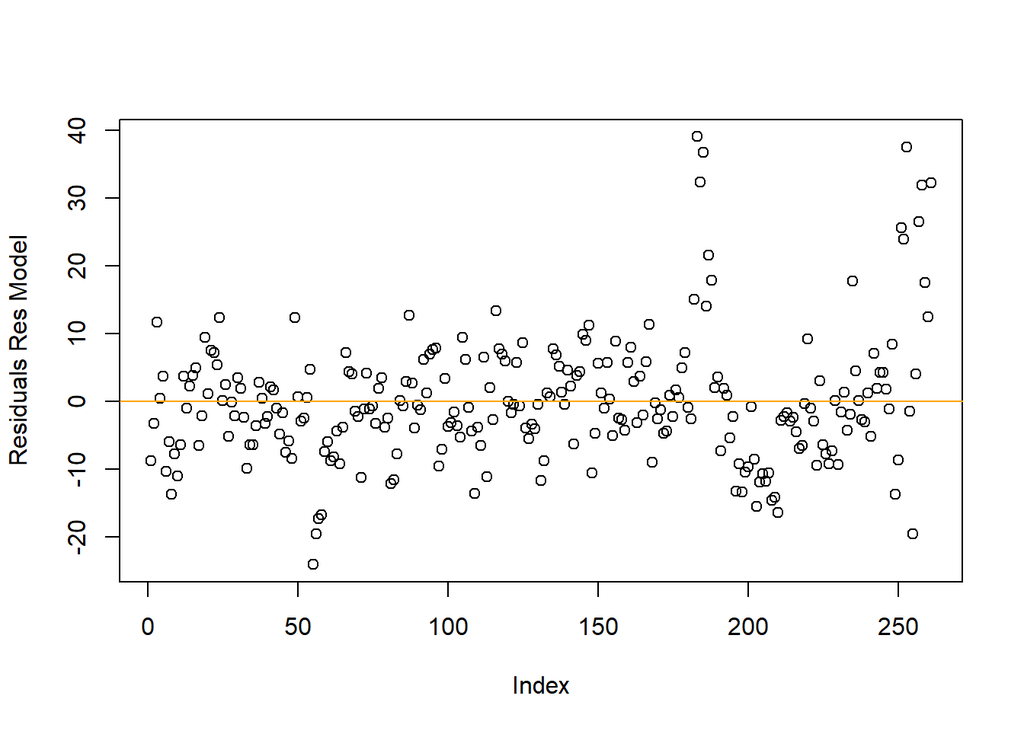

```r
plot(EcoMod_TOT$residuals, ylab="Residuals TOT Model")
abline(h=0, col="orange")

plot(EcoMod_VIS$residuals, ylab="Residuals VIS Model")
abline(h=0, col="orange")

plot(EcoMod_NIR$residuals, ylab="Residuals NIR Model")
abline(h=0, col="orange")

plot(EcoMod_Res$residuals, ylab="Residuals Res Model")
abline(h=0, col="orange")
```

## Tree

### Prepare Data

```r
# Phylogeny
trees <- ape::read.tree("../Data/XMAS_mat2b_bst2ef_set23nn2_pinct.nwk ")
```

Read and prune the MCC tree

The MCC (Maximum clade credibility) tree plotted here is the BEAST MCC tree.

```r
# read the tree
MCCtree.raw <-
  ape::read.nexus("../Data/xmas_mat2b_bst2ef_set23nn2_pinct_med.tre")

# Prune extra spp in the tree, not contain in the test sample
species.MCC <- as.data.frame(unique(Cons1$phylogeny_name))

# Convert to "row names" (required for following steps)
row.names(species.MCC) <- species.MCC[, 1]

# Make sure the names in data set and tree match
temp.MCC <- name.check(MCCtree.raw, species.MCC)

# This step would be neccesary if the tips had been different.
# MCCtree <- drop.tip(MCCtree.raw, temp.MCC$tree_not_data)
# Not used in our case.

# Instead, changed the name
MCCtree <- MCCtree.raw
```

### Plot the tree

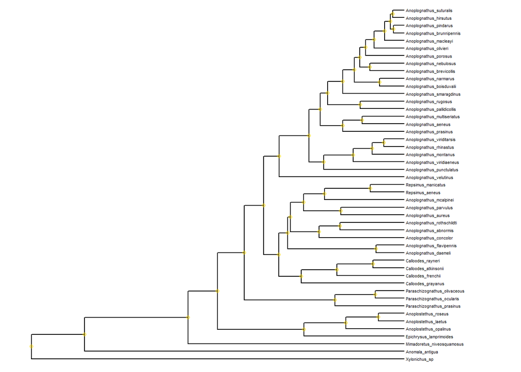

```r
# create phylogeny object for ggtree()
phylo.MCC <- ggtree(MCCtree, layout="rectangular") + geom_tiplab(size = 1.5)

# set xlim
phylo.MCC + xlim(0, 25) +
  geom_nodepoint(col="gold", alpha=0.4)
```

### Plot the traits on the tree

The reflectivity values that we include in this plot has to be the average between individuals, since there is only one branch per species. Thus, calculations are done based on the data frame `ConsAgg` (see section Data Processiong / Consolidated Data Frames / Reflectivity per species )

p1 and p2 are two basic plots containing size and ecological variables p1 contains results of PC1 and p2 the results of PC2

```r
# create a MCC tree without tip names for the plot
tree_only <- ggtree(MCCtree, layout="rectangular")

# create heat map columns
# Note: log transforms increase contrast for visualization purposes

# Add Size
p0 <- gheatmap(tree_only, Sizdf,
  width = 0.05, low = "gray90", high = "black",
  font.size = 2,
  colnames_position = "bottom", colnames_angle = 0,
  colnames_offset_x = 0, colnames_offset_y = -0.5,
  legend_title = "Size")

# Add PCs

p1.scale <- p0 + new_scale_fill() # add new scale for second variable
p1 <- gheatmap(p1.scale, (PC1df),
  offset = 1.5, # to avoid overlapping with p1
  width = 0.05, low = "#bd1a26", high = "#fffecc",
  font.size = 2,
  colnames_position = "bottom", colnames_angle = 0,
  colnames_offset_x = 0, colnames_offset_y = -0.5,
  legend_title = "PC1")

p2.scale <- p0 + new_scale_fill() # add new scale for second variable
p2 <- gheatmap(p2.scale, (PC2df),
  offset = 1.5, # to avoid overlapping with p1
  width = 0.05, low = "red", high = "gold",
  font.size = 2,
  colnames_position = "bottom", colnames_angle = 0,
  colnames_offset_x = 0, colnames_offset_y = -0.5,
  legend_title = "PC2")
```

The basic plots can be combined with reflectivity on any band (TOT, VIS and NIR), and residuals

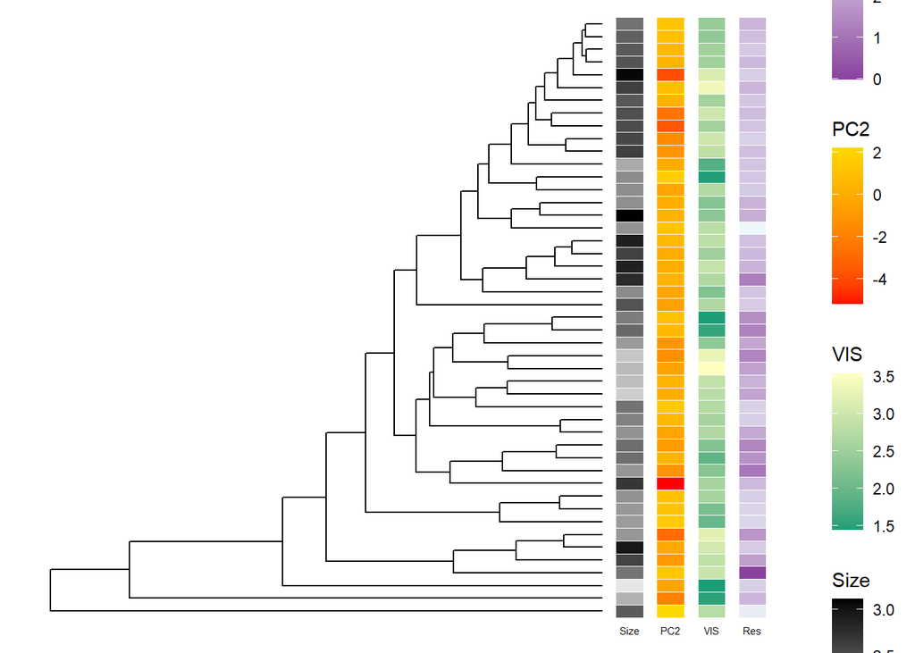

```r
# Add Reflectance

# VIS
p3.scale <- p2 + new_scale_fill() # add new scale for second variable
p3 <- gheatmap(p3.scale, log(VISdf),
  offset = 3, # to avoid overlapping with p1
  width = 0.05, low = "#1b9e77", high = "#FFFFBF",
  font.size = 2,
  colnames_position = "bottom", colnames_angle = 0,
  colnames_offset_x = 0, colnames_offset_y = -0.5,
  legend_title = "VIS")

# Res
p4.scale <- p3 + new_scale_fill() # add new scale for second variable
p4 <- gheatmap(p4.scale,
               log(Resdf+ # get log to bring them closer to each other
                     (abs((min(Resdf)))+1)# make them all positive
                   ), # this correction allows better visualization
  offset = 4.5,
  width = 0.05, low = "#88419d", high = "#edf8fb",
  font.size = 2,
  colnames_position = "bottom", colnames_angle = 0,
  colnames_offset_x = 0, colnames_offset_y = -0.5,
  legend_title = "Res")

p4
```

## MCMC Model

This model tests if the correlations we found in the previous step remain after correcting by phylogeny. This models considers the instraspecific differences in both the reflectivity and the location

Note:

We use an inverse Wishart prior for the variances and parameter expanded priors for the random effects. Specifically, we use the inverse-gamma prior (V=1) with scale and shape equal to 0.001 (nu=0.002). For parameter expanded priors, we use V=1, nu=1, alpha.mu=0, which is equivalent to a proper Cauchy prior for the standard deviation with scale equal to square-root(alpha.V.). Here we used alpha.V=25^2 following Gelman.2006.

*With V=1 these distributions are equivalent to inverse gamma distributions with shape and scale parameters set to nu/2.*

### Set priors for MCMC

```r
# Include 2 Gs = 2 random factors:
# 1) species (multiple individuals per species) = "phylogeny_name"
# 2) phylogeny (phylogenetic relatedness) = "animal"

prior <- list(
  R = list(V = 1, n = 0.002),
  G = list(
    G1 = list(V = 1, n = 1, alpha.mu = 0, alpha.V = 25^2),
    G2 = list(V = 1, n = 1, alpha.mu = 0, alpha.V = 25^2)
  )
)
```

### On the MCC tree only

Prepare data sets

```r
ALLDataSet <-
  Cons1 %>%
  dplyr::select (-R_VIS, -R_NIR, - Res) %>%
  rename ("Reflectance" = R_ALL) %>%
  dplyr::select (ind, phylogeny_name, everything())


NIRDataSet <-
  Cons1 %>%
  dplyr::select (-R_ALL, -R_VIS, - Res) %>%
  rename ("Reflectance" = R_NIR) %>%
  dplyr::select (ind, phylogeny_name, everything())


VISDataSet <-
  Cons1 %>%
  dplyr::select (-R_ALL, -R_NIR, - Res) %>%
  rename ("Reflectance" = R_VIS) %>%
  dplyr::select (ind, phylogeny_name, everything())


ResDataSet <-
  Cons1 %>%
  dplyr::select (-R_ALL, -R_NIR, -R_VIS) %>%
  rename ("Reflectance" = Res) %>%
  dplyr::select (ind, phylogeny_name, everything())
```

Set up the model

```r
mcmcmodel <- Reflectance ~ PC1 + PC2 + size + PC1*size + PC2*size
```

Parameters for the model: nitt = 3000, burnin = 500, thin = 1. Set up a shared inverseA and sub-datasets for the MCC tree analysis

```r
AinvTA.MCC <- inverseA(MCCtree)$Ainv

ALLDataSet$animal <- factor(ALLDataSet$phylogeny_name)

NIRDataSet$animal <- factor(NIRDataSet$phylogeny_name)

VISDataSet$animal <- factor(VISDataSet$phylogeny_name)

ResDataSet$animal <- factor(ResDataSet$phylogeny_name)
```

Note: In the plots, the trace should span across the y axis to show that the model have reached all the possibilities.

In the density plots, if the center of the distribution is away from zero, the variable is effective on the dependent variable. The n value in the figure equals to the trees we saved from the model, here: 3000(nitt) - 500(burnin) = 2500.

#### ALL Reflectivity

```r
mcmcModMCC_ALL <- MCMCglmm(mcmcmodel,
  random = ~ animal + phylogeny_name,
  # account for phylogeny info and species as random factors
  prior = prior,
  ginverse = list(animal = AinvTA.MCC),
  # because "animal" that accounts for phylogeny
  data = ALLDataSet,
  family = "gaussian", # depends on the distribution of the parameter
  nitt = 3000, burnin = 500, thin = 1, # just to get the chains start
  # Since this is only one round, increase this number to increase reliability
  pl = T,
  pr = F,
  verbose = F,
  singular.ok = T
)

summary(mcmcModMCC_ALL)$solutions %>%
  kbl() %>%
  kable_paper("hover", full_width = F)
```

|  | post.mean | l-95% CI | u-95% CI | eff.samp | pMCMC |
| --- | --- | --- | --- | --- | --- |
| (Intercept) | 21.1609629 | 3.2708489 | 39.702672 | 2500.000 | 0.0264 |
| PC1 | 0.0568480 | -4.1072580 | 4.165824 | 2000.038 | 0.9960 |
| PC2 | 0.9176831 | -4.0401753 | 5.909181 | 2500.000 | 0.7032 |
| size | 3.9147525 | -0.5197341 | 8.080780 | 2500.000 | 0.0872 |
| PC1:size | -0.0153881 | -1.7234376 | 1.745718 | 1950.161 | 0.9960 |
| PC2:size | -0.4596880 | -2.4523331 | 1.587377 | 2500.000 | 0.6528 |

```r
# plot(mcmcModMCC_VIS) can be used to check the progress of the model
```

#### NIR Reflectivity

```r
mcmcModMCC_NIR <- MCMCglmm(mcmcmodel,
  random = ~ animal + phylogeny_name,
  # account for phylogeny info and species as random factors
  prior = prior,
  ginverse = list(animal = AinvTA.MCC),
  # because "animal" that accounts for phylogeny
  data = NIRDataSet,
  family = "gaussian", # depends on the distribution of the parameter
  nitt = 3000, burnin = 500, thin = 1, # just to get the chains start
  # Since this is only one round, increase this number to increase reliability
  pl = T,
  pr = F,
  verbose = F,
  singular.ok = T
)

summary(mcmcModMCC_ALL)$solutions %>%
  kbl() %>%
  kable_paper("hover", full_width = F)
```

[output not shown]

```r
# plot(mcmcModMCC_VIS) can be used to check the progress of the model
```

#### VIS Reflectivity

```r
mcmcModMCC_VIS <- MCMCglmm(mcmcmodel,
  random = ~ animal + phylogeny_name,
  # account for phylogeny info and species as random factors
  prior = prior,
  ginverse = list(animal = AinvTA.MCC),
  # because "animal" that accounts for phylogeny
  data = VISDataSet,
  family = "gaussian", # depends on the distribution of the parameter
  nitt = 3000, burnin = 500, thin = 1, # just to get the chains start
  # Since this is only one round, increase this number to increase reliability
  pl = T,
  pr = F,
  verbose = F,
  singular.ok = T
)

summary(mcmcModMCC_VIS)$solutions %>%
  kbl() %>%
  kable_paper("hover", full_width = F)
```

|  | post.mean | l-95% CI | u-95% CI | eff.samp | pMCMC |
| --- | --- | --- | --- | --- | --- |
| (Intercept) | 7.3227271 | -6.566280 | 21.207750 | 2821.522 | 0.2904 |
| PC1 | -0.1388852 | -3.495319 | 3.224806 | 1326.829 | 0.9160 |
| PC2 | 0.7578721 | -3.649700 | 4.585561 | 2500.000 | 0.6960 |
| size | 2.3298563 | -1.255521 | 5.800982 | 2500.000 | 0.2024 |
| PC1:size | -0.0506623 | -1.522462 | 1.335611 | 1397.137 | 0.9688 |
| PC2:size | -0.4699517 | -1.959673 | 1.390944 | 2500.000 | 0.5624 |

```r
# plot(mcmcModMCC_VIS) can be used to check the progress of the model
```

#### Residuals

```r
mcmcModMCC_Res <- MCMCglmm(mcmcmodel,
  random = ~ animal + phylogeny_name,
  # account for phylogeny info and species as random factors
  prior = prior,
  ginverse = list(animal = AinvTA.MCC),
  # because "animal" that accounts for phylogeny
  data = ResDataSet,
  family = "gaussian", # depends on the distribution of the parameter
  nitt = 3000, burnin = 500, thin = 1, # just to get the chains start
  # Since this is only one round, increase this number to increase reliability
  pl = T,
  pr = F,
  verbose = F,
  singular.ok = T
)

summary(mcmcModMCC_Res)$solutions %>%
    kbl() %>%
    kable_paper("hover", full_width = F)
```

|  | post.mean | l-95% CI | u-95% CI | eff.samp | pMCMC |
| --- | --- | --- | --- | --- | --- |
| (Intercept) | 1.0252570 | -15.640245 | 17.795668 | 1811.992 | 0.9136 |
| PC1 | 0.7379471 | -3.918481 | 4.958119 | 2500.000 | 0.7376 |
| PC2 | 1.3846228 | -4.557274 | 6.596117 | 1954.270 | 0.6128 |
| size | 1.9085909 | -2.644809 | 6.612691 | 2158.418 | 0.4232 |
| PC1:size | -0.0942095 | -1.920272 | 1.871472 | 2500.000 | 0.9320 |
| PC2:size | -0.3794540 | -2.512837 | 2.018247 | 1984.076 | 0.7240 |

```r
# plot(mcmcModMCC_VIS) can be used to check the progress of the model
```

### On multiple trees

```r
source("code_run_mcmc.R") # Function with MCMCglmm through trees
```

#### ALL Reflectivity

```r
mcmc.reg.ALL <- run_mcmc(trees, mcmcmodel, ALLDataSet)
```

```r
summary(mcmc.reg.ALL)$solutions %>%
  round(3) %>%
  kbl() %>%
  kable_paper("hover", full_width = F)
```

|  | post.mean | l-95% CI | u-95% CI | eff.samp | pMCMC |
| --- | --- | --- | --- | --- | --- |
| (Intercept) | 21.925 | 4.044 | 36.086 | 1300.000 | 0.009 |
| PC1 | 0.217 | -4.135 | 4.806 | 1300.000 | 0.915 |
| PC2 | 0.555 | -4.471 | 5.688 | 1300.000 | 0.840 |
| size | 3.605 | -0.543 | 8.229 | 1179.215 | 0.109 |
| PC1:size | -0.106 | -2.060 | 1.723 | 1300.000 | 0.915 |
| PC2:size | -0.274 | -2.338 | 1.794 | 1300.000 | 0.826 |

#### NIR Reflectivity

```r
mcmc.reg.NIR <- run_mcmc(trees, mcmcmodel, NIRDataSet)
```

```r
summary(mcmc.reg.NIR)$solutions %>%
  round(3) %>%
  kbl() %>%
  kable_paper("hover", full_width = F)
```

|  | post.mean | l-95% CI | u-95% CI | eff.samp | pMCMC |
| --- | --- | --- | --- | --- | --- |
| (Intercept) | 35.046 | 12.088 | 53.690 | 1300.000 | 0.001 |
| PC1 | 0.649 | -4.601 | 7.059 | 829.684 | 0.845 |
| PC2 | 0.895 | -5.633 | 8.167 | 1300.000 | 0.822 |
| size | 4.653 | -1.481 | 10.722 | 1300.000 | 0.128 |
| PC1:size | -0.190 | -2.771 | 2.198 | 1186.085 | 0.863 |
| PC2:size | -0.316 | -3.076 | 2.606 | 1300.000 | 0.845 |

#### VIS Reflectivity

```r
mcmc.reg.VIS <- run_mcmc(trees, mcmcmodel, VISDataSet)
```

```r
summary(mcmc.reg.VIS)$solutions %>%
  round(3) %>%
  kbl() %>%
  kable_paper("hover", full_width = F)
```

|  | post.mean | l-95% CI | u-95% CI | eff.samp | pMCMC |
| --- | --- | --- | --- | --- | --- |
| (Intercept) | 6.951 | -4.702 | 21.765 | 1300.000 | 0.308 |
| PC1 | -0.463 | -3.513 | 3.360 | 1300.000 | 0.734 |
| PC2 | 0.628 | -3.350 | 4.600 | 1300.000 | 0.737 |
| size | 2.398 | -1.119 | 6.042 | 1301.201 | 0.172 |
| PC1:size | 0.072 | -1.439 | 1.428 | 1300.000 | 0.871 |
| PC2:size | -0.430 | -2.045 | 1.218 | 1300.000 | 0.592 |

#### Residuals

```r
mcmc.reg.Res <- run_mcmc(trees, mcmcmodel, ResDataSet)
```

```r
summary(mcmc.reg.Res)$solutions %>%
  round(3) %>%
  kbl() %>%
  kable_paper("hover", full_width = F)
```

|  | post.mean | l-95% CI | u-95% CI | eff.samp | pMCMC |
| --- | --- | --- | --- | --- | --- |
| (Intercept) | 0.974 | -15.875 | 18.705 | 1153.148 | 0.914 |
| PC1 | 0.803 | -3.728 | 5.115 | 1178.086 | 0.732 |
| PC2 | 1.358 | -3.812 | 7.614 | 1300.000 | 0.614 |
| size | 1.947 | -2.438 | 6.821 | 1147.916 | 0.408 |
| PC1:size | -0.125 | -1.975 | 1.843 | 1300.000 | 0.886 |
| PC2:size | -0.368 | -2.770 | 1.811 | 1199.555 | 0.738 |

### Model Convergency

obtain the ``trace’’ of the sampling (to check for convergence and auto-correlation) and posterior density of each parameter.

If the model has converged there should be no trend in the time series. If it’s not spanning all over, it means that the trace for the residual variance has strong auto-correlation and needs to be run for longer.

In the density plots, if the center of the distribution away from zero, meaning that the variable is effective on the dependent variable. The n value in the figure equals to the trees we saved from the model, nitt# - burnin#.

#### ALL Reflectivity

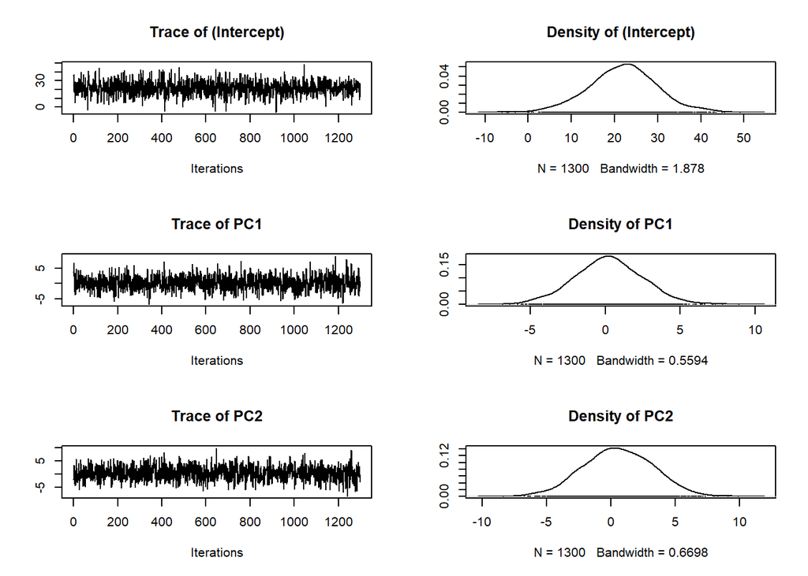

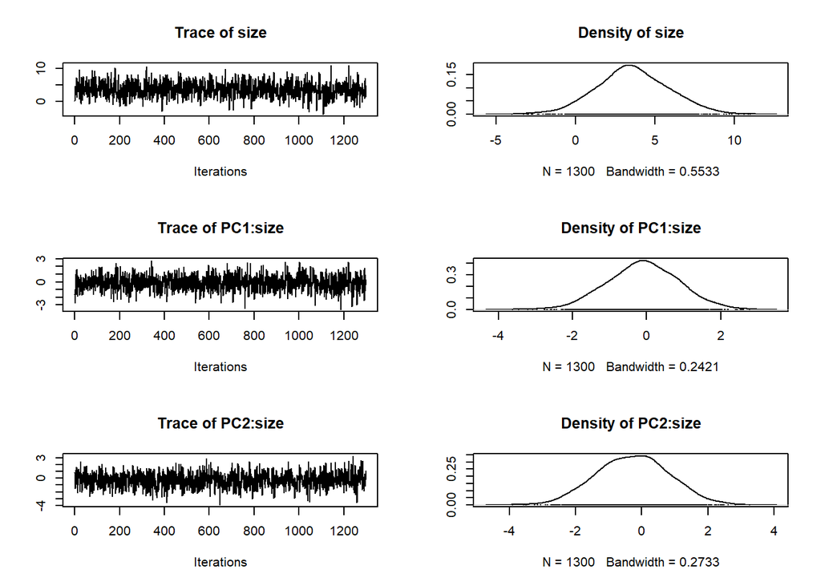

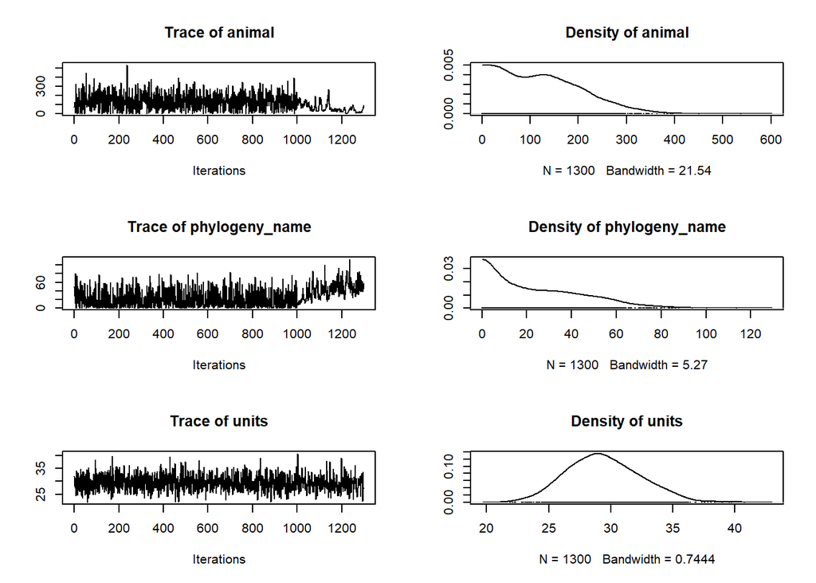

```r
plot(mcmc.reg.ALL)
```

#### NIR Reflectivity

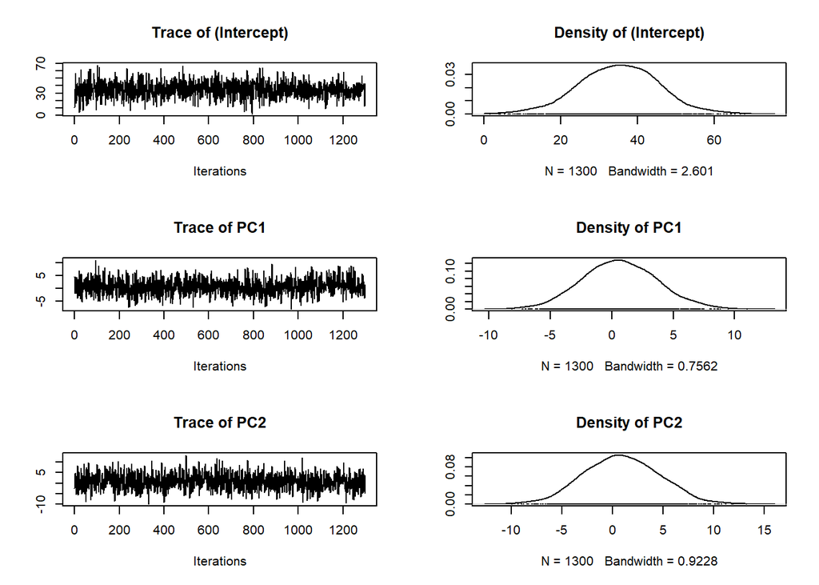

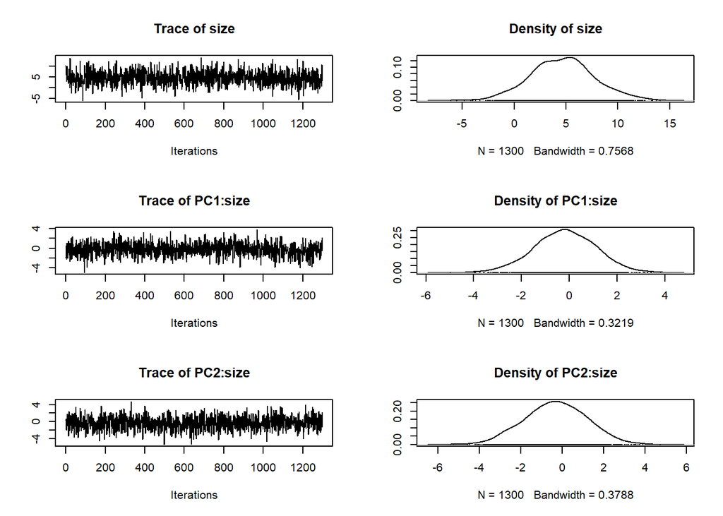

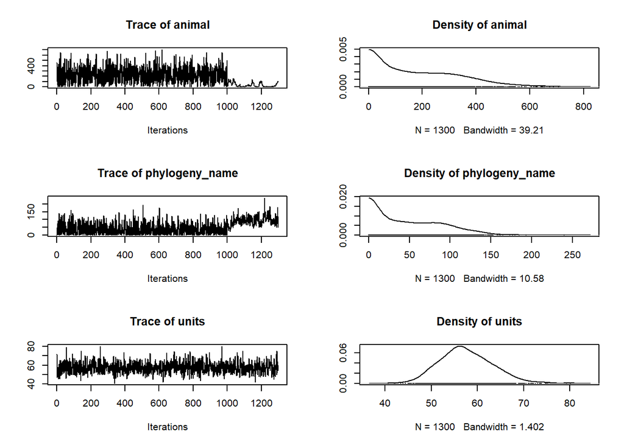

```r
plot(mcmc.reg.NIR)
```

#### VIS Reflectivity

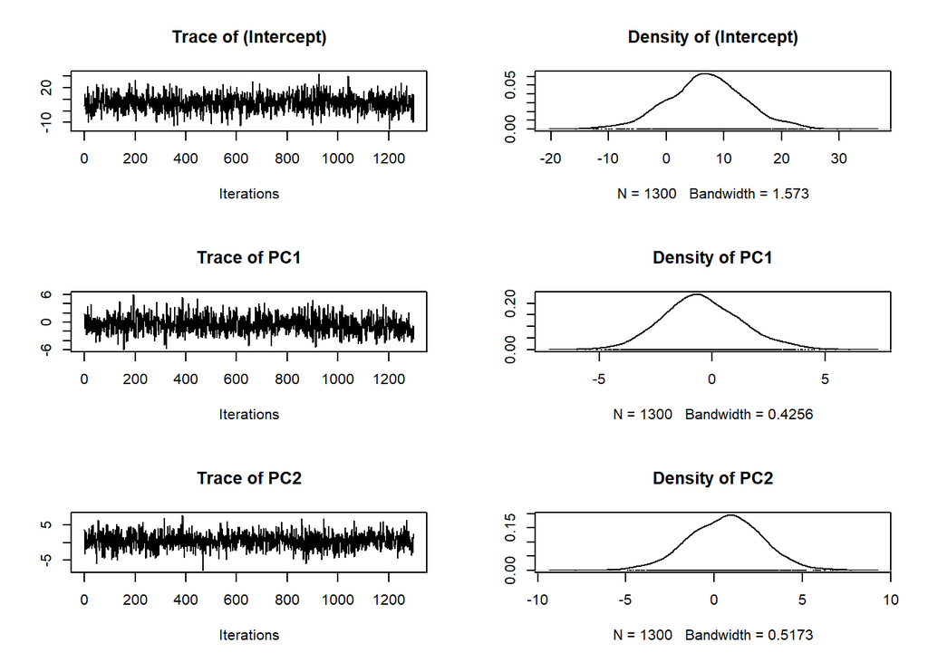

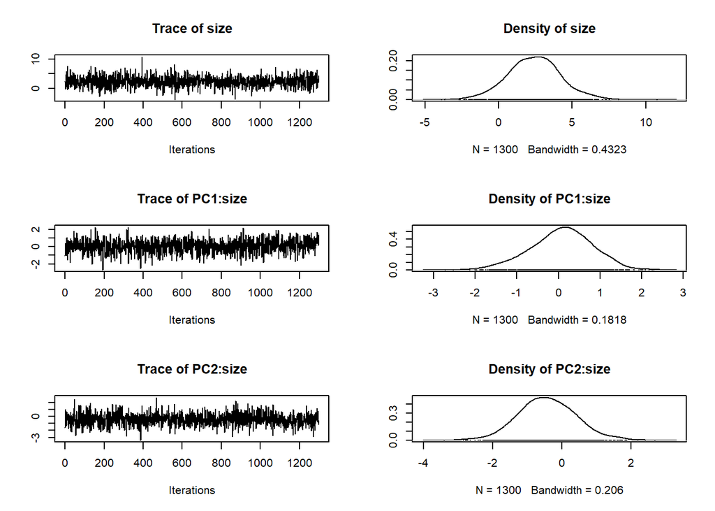

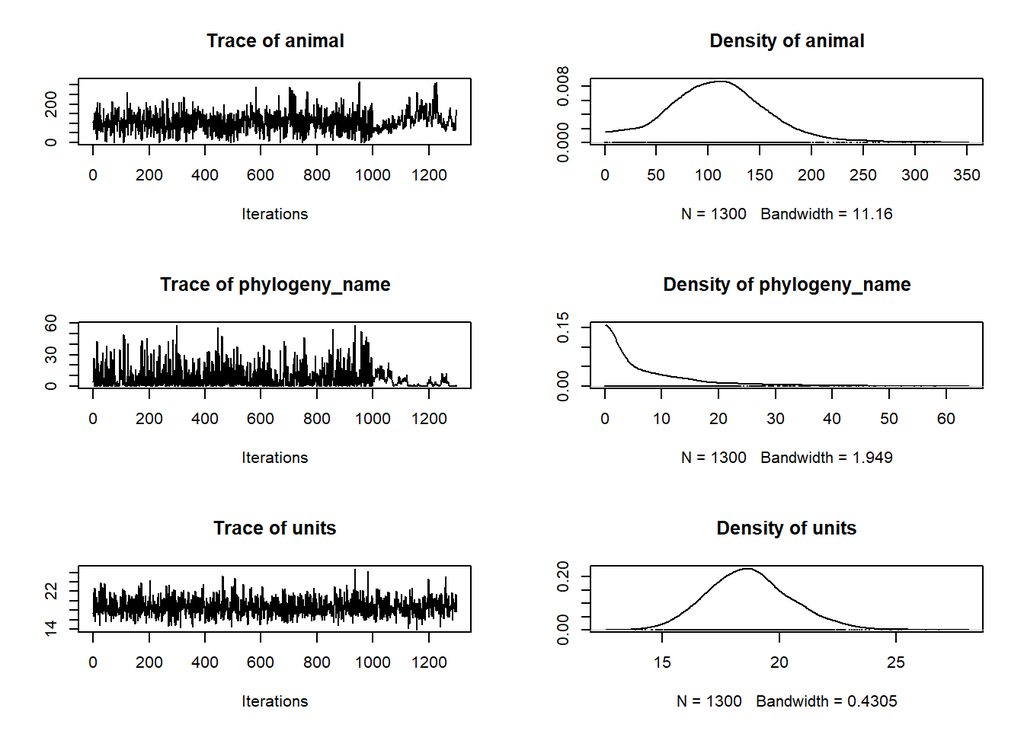

```r
plot(mcmc.reg.VIS)
```

#### Residuals

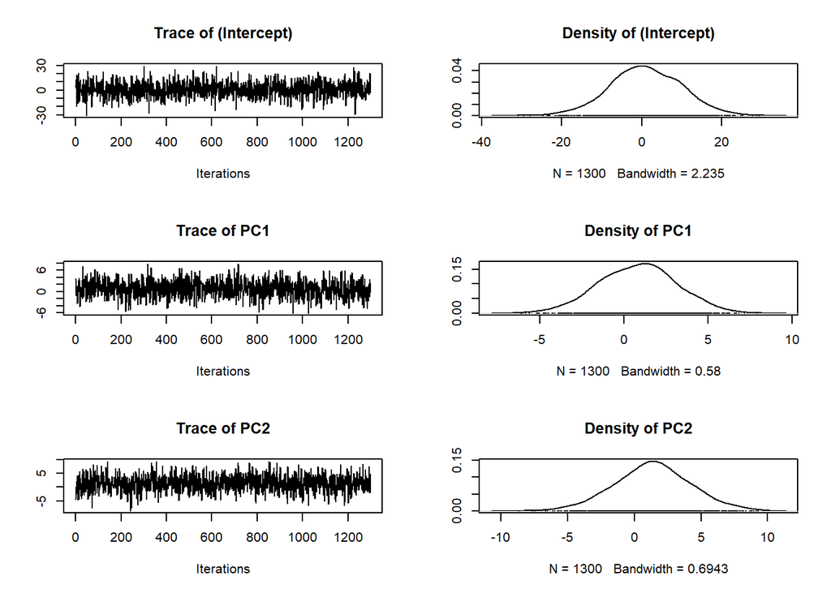

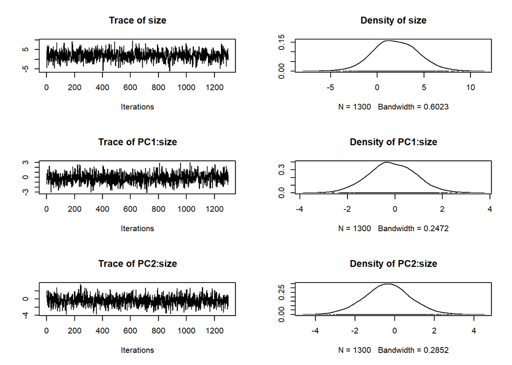

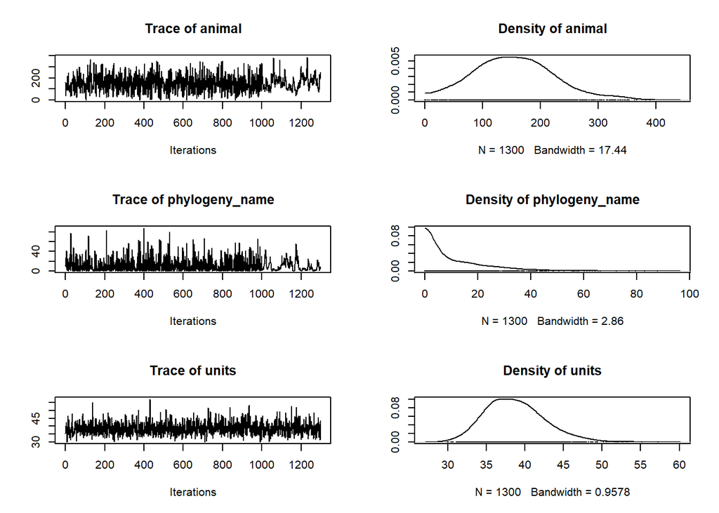

```r
plot(mcmc.reg.Res)
```

## PGLS

This model tests if the correlations we found in the previous step remain after correcting by phylogeny. This model does not consider instraspecific variation. We averaged both location and reflectivity and obtained only one value per species.

Model is the same used for MCMCglmm

Make sure names between data and tree tips match

```r
Cons1agg <- as.data.frame(Cons1agg)
row.names(Cons1agg) <- Cons1agg [, 1]
names(Cons1agg) <- c("phylogeny_name", "TOT", "VIS", "NIR", "Res",
                     "PC1", "PC2", "size")


# Test if the species are the same
identical(
  length(name.check(MCCtree, Cons1agg$phylogeny_name)$tree_not_data),
  length(Cons1agg$phylogeny_name)
)
```

```
## [1] TRUE
```

```r
# name.check(MCCtree, Cons1agg$phylogeny_name)
```

Set up:

```r
comp_data <- comparative.data(
  phy = MCCtree, data = Cons1agg,
  names.col = "phylogeny_name", vcv = TRUE,
  na.omit = FALSE, warn.dropped = TRUE
)
```

### ALL Reflectivity

```r
pglsmodTOT <- pgls(TOT ~ PC1 + PC2 + size + PC1*size + PC2*size,
  data = comp_data, param.CI = 0.95, lambda = "ML"
)

summary(pglsmodTOT)
```

```
##
## Call:
## pgls(formula = TOT ~ PC1 + PC2 + size + PC1 * size + PC2 * size,
##     data = comp_data, lambda = "ML", param.CI = 0.95)
##
## Residuals:
##     Min      1Q  Median      3Q     Max
## -9.3170 -1.9757 -0.5206  1.0887  6.1912
##
## Branch length transformations:
##
## kappa  [Fix]  : 1.000
## lambda [ ML]  : 1.000
##    lower bound : 0.000, p = 0.038354
##    upper bound : 1.000, p = 1
##    95.0% CI   : (0.661, NA)
## delta  [Fix]  : 1.000
##
## Coefficients:
##             Estimate Std. Error t value Pr(>|t|)
## (Intercept) 15.35085   12.36260  1.2417   0.2214
## PC1         -5.86238    3.95093 -1.4838   0.1455
## PC2         -0.95187    4.87412 -0.1953   0.8461
## size         6.16039    3.83390  1.6068   0.1158
## PC1:size     2.72478    1.68384  1.6182   0.1133
## PC2:size     0.30993    1.94058  0.1597   0.8739
##
## Residual standard error: 3.542 on 41 degrees of freedom
## Multiple R-squared: 0.1787,  Adjusted R-squared: 0.07853
## F-statistic: 1.784 on 5 and 41 DF,  p-value: 0.1376
```

Results after correcting by phylogeny:

None of the variables has an effect in the total reflectance

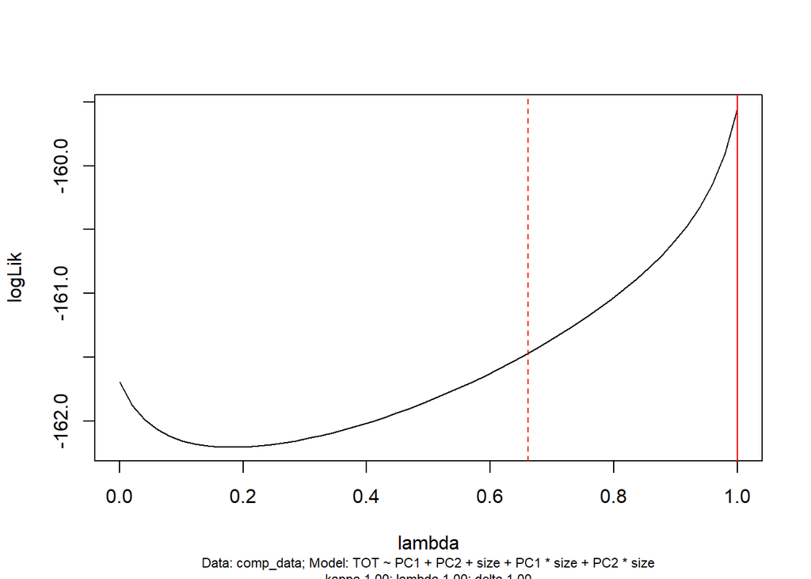

```r
# visualize a likelihood surface
lm.lk.TOT <- pgls.profile(pglsmodTOT, which = "lambda")
plot(lm.lk.TOT)
```

Model diagnostic plots

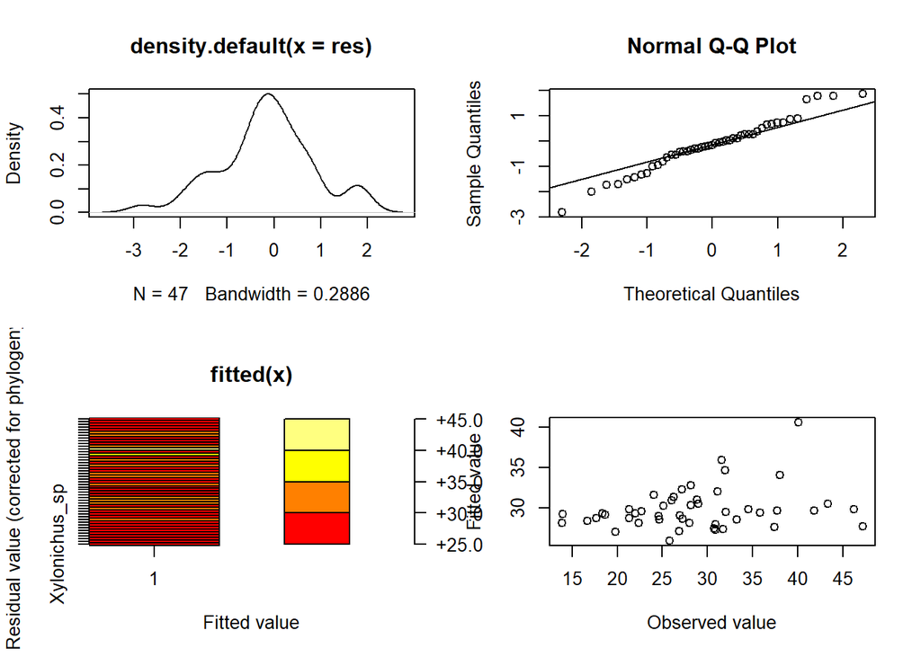

```r
par(mfrow = c(2, 2))
plot(pglsmodTOT)
```

Test phylogenetic signal using Pagel’s lambda

```r
pagelTOTRefl <- Cons1agg$TOT # Define which trait you want to test
names(pagelTOTRefl) <- rownames(Cons1agg) # Row names = tree tips
phylosig(MCCtree, pagelTOTRefl, method = "lambda", test = TRUE, nsim = 999)
```

```
##
## Phylogenetic signal lambda : 0.819728
## logL(lambda) : -163.269
## LR(lambda=0) : 0.319604
## P-value (based on LR test) : 0.571846
```

```r
# nsim = 999 means testing with 999 randomizations
```

### NIR Reflectivity

```r
pglsmodNIR <- pgls(NIR ~ PC1 + PC2 + size + PC1*size + PC2*size,
  data = comp_data, param.CI = 0.95, lambda = "ML"
)

summary(pglsmodNIR)
```

```
##
## Call:
## pgls(formula = NIR ~ PC1 + PC2 + size + PC1 * size + PC2 * size,
##     data = comp_data, lambda = "ML", param.CI = 0.95)
##
## Residuals:
##      Min       1Q   Median       3Q      Max
## -10.2487  -2.5614  -0.6293   1.9375  10.0815
##
## Branch length transformations:
##
## kappa  [Fix]  : 1.000
## lambda [ ML]  : 1.000
##    lower bound : 0.000, p = 0.02704
##    upper bound : 1.000, p = 1
##    95.0% CI   : (0.635, NA)
## delta  [Fix]  : 1.000
##
## Coefficients:
##             Estimate Std. Error t value Pr(>|t|)
## (Intercept)  33.7981    16.2677  2.0776  0.04405 *
## PC1          -5.5781     5.1990 -1.0729  0.28958
## PC2           4.4288     6.4138  0.6905  0.49376
## size          5.3239     5.0450  1.0553  0.29747
## PC1:size      2.7294     2.2157  1.2318  0.22503
## PC2:size     -1.7527     2.5536 -0.6864  0.49635
## ---
## Signif. codes:  0 '***' 0.001 '**' 0.01 '*' 0.05 '.' 0.1 ' ' 1
##
## Residual standard error: 4.66 on 41 degrees of freedom
## Multiple R-squared: 0.1679,  Adjusted R-squared: 0.06639
## F-statistic: 1.654 on 5 and 41 DF,  p-value: 0.1675
```

Results after correcting by phylogeny:

None of the variables has an effect in the NIR reflectance

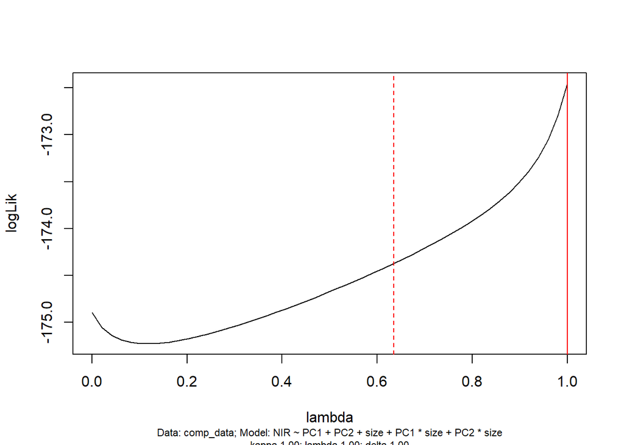

```r
# visualize a likelihood surface
lm.lk.NIR <- pgls.profile(pglsmodNIR, which = "lambda")
plot(lm.lk.NIR)
```

Model diagnostic plots

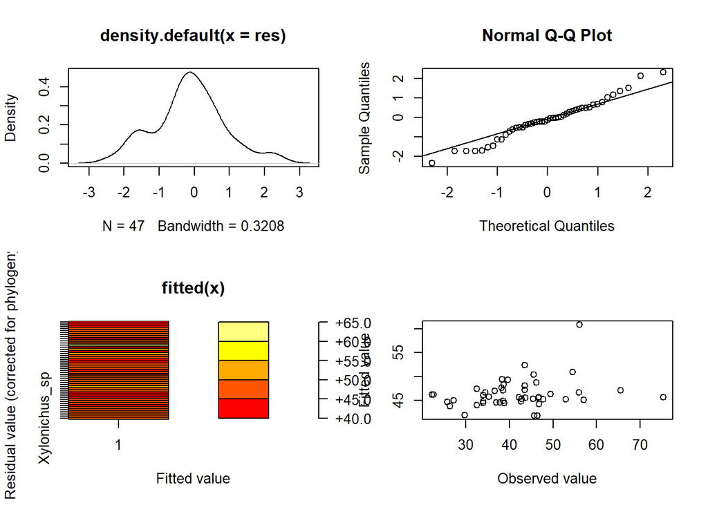

```r
par(mfrow = c(2, 2))
plot(pglsmodNIR)
```

Test phylogenetic signal using Pagel’s lambda

```r
pagelNIRRefl <- Cons1agg$NIR # Define which trait you want to test
names(pagelNIRRefl) <- rownames(Cons1agg) # Row names = tree tips
phylosig(MCCtree, pagelNIRRefl, method = "lambda", test = TRUE, nsim = 999)
```

```
##
## Phylogenetic signal lambda : 0.816089
## logL(lambda) : -175.925
## LR(lambda=0) : 1.47387
## P-value (based on LR test) : 0.224736
```

```r
# nsim = 999 means testing with 999 randomizations
```